# Estimation of the MLB talent pool; Supplement to Comparing baseball players across eras via novel Full House Modeling

Shen Yan, Adrian Burgos Jr., Christopher Kinson, and Daniel J. Eck

We load in the necessary software packages used in this analysis.

```r
library(Lahman)
library(tidyverse)
library(ggplot2)
library(splines)
```

## MLB Demographics

We load in the Batting and Pitching data sets in the [Lahman R package](https://cran.r-project.org/web/packages/Lahman/Lahman.pdf) and isolate the birth state and birth country for every MLB player in history (as recorded by the [Lahman Database](https://www.seanlahman.com/baseball-archive/statistics/) and implemented in the [Lahman R package](https://cran.r-project.org/web/packages/Lahman/Lahman.pdf)). Missing entries are discarded.

```r
foo_bat = Batting %>% dplyr::select(playerID, yearID) %>%
  left_join(People %>% dplyr::select(playerID, birthCountry, birthState))
foo_pit = Pitching %>% dplyr::select(playerID, yearID) %>%
  left_join(People %>% dplyr::select(playerID, birthCountry, birthState))

## adjust for missingness
foo_tot = rbind(foo_bat, foo_pit) %>% distinct()
foo_tot[is.na(foo_tot$birthCountry), ]$birthCountry = "missing"
foo_tot[!is.na(foo_tot$birthCountry) &
          is.na(foo_tot$birthState), ]$birthState = "missing"
```

We add a regions variable which will allow us to plot the proportion of MLB players from each region over time (0 will indicate an international player).

```r
NMLB = foo_tot %>% group_by(yearID) %>%
  summarise(N = n())

state_perc = foo_tot %>%
  group_by(yearID, birthState, birthCountry) %>%
  summarise(yearID, birthState, birthCountry, Nstate = n()) %>%
  distinct() %>%
  left_join(NMLB) %>%
  mutate(state_perc = Nstate/N) %>%
  mutate(region = ifelse(birthState %in% c("CT", "MA", "DE", "ME", "NH",
                                           "NJ", "NY", "PA", "VT", "RI"), "NE", "0"),
         region = ifelse(birthState %in% c("IL", "IN", "MI", "OH", "WI",
                                           "IA", "KS", "MN", "MO", "NE", "ND", "SD"),
                         "MW", region),
         region = ifelse(birthState %in% c("WA", "MT", "ID", "WY", "OR",
                                           "CA", "NV", "UT", "CO", "AZ",
                                           "NM"), "W", region),
         region = ifelse(birthCountry == "USA" & region == "0", "S", region),
         region = ifelse(region == "0", "INTL", region))
```

We now plot the proportion of MLB players from each region. From this we see that baseball was primarily a Northeastern and Midwestern game in the early years. We can also see that the game became more and more international beginning around integration in 1947. This is consistent with [Armour and Levitt (2016)](https://sabr.org/bioproj/topic/baseball-demographics-1947-2016/).

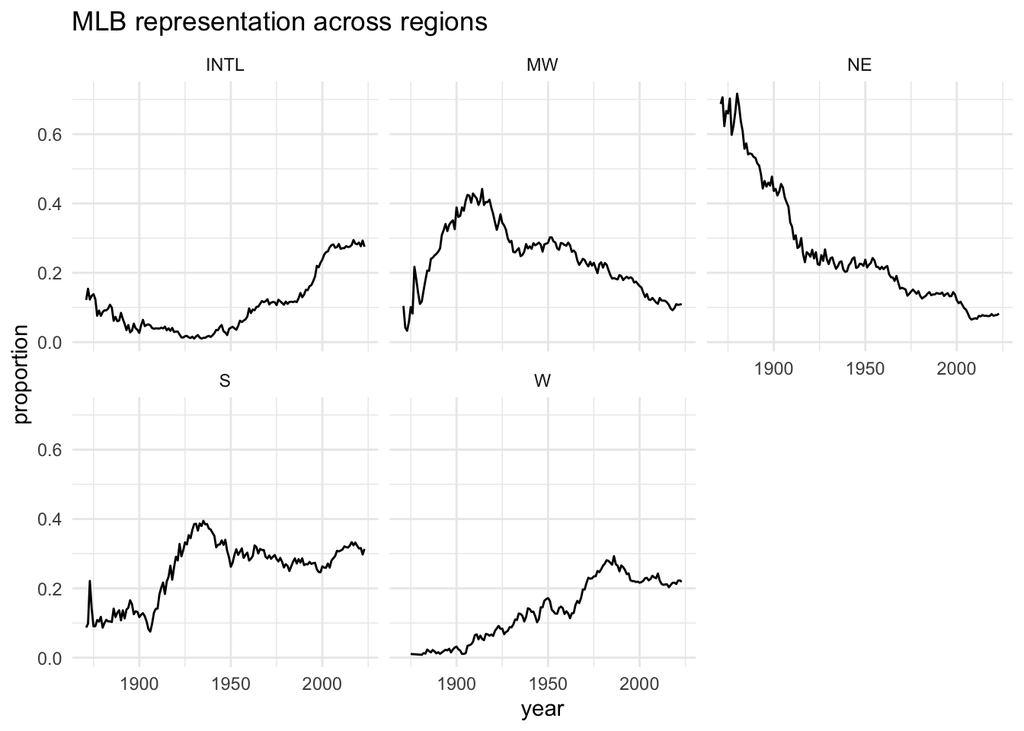

```r
region_perc = state_perc %>% group_by(yearID, region) %>%
  summarise(region_perc = sum(state_perc))

## By region
ggplot(region_perc, aes(x = yearID, y = region_perc)) +
  geom_line() +
  facet_wrap(~region) +
  labs(title = "MLB representation across regions",
       y = "proportion",
       x = "year") +
  theme_minimal()
```

Even into the 1950s and early 1960s, baseball was primarily a NE and MW game, with the South on par with the MW region in this period. This balance of MLB regional representation coincides with, [as recently as 1958](https://en.wikipedia.org/wiki/Major_League_Baseball_relocations_of_1950s%E2%80%931960s), no MLB team residing further West or South than St Louis.

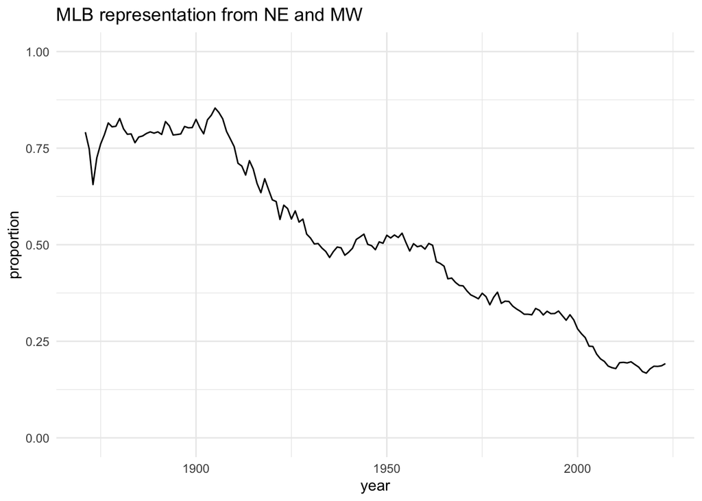

```r
ggplot(region_perc %>%
  mutate(NEpMW = ifelse(region %in% c("MW", "NE"),1,0)) %>%
  filter(NEpMW == 1) %>%
  group_by(yearID) %>%
  summarise(NEplusMW_perc = sum(region_perc)),
  aes(x = yearID, y = NEplusMW_perc)) +
  geom_line() +
  labs(title = "MLB representation from NE and MW",
       y = "proportion",
       x = "year") +
  ylim(0,1) +
  theme_minimal()
```

## Population

We first obtain US Census counts of aged 20-29 white males from 1870 to 1940, and we obtain US Census counts of all aged 20-29 males for 1950. Baseball began the integration process in 1947. Inclusion of the US Black population into the 1950 count likely overstates the participation of this population in the MLB at this time due to continued segregation (See [Armour and Levitt (2016)](https://sabr.org/bioproj/topic/baseball-demographics-1947-2016/) for details of MLB demographics). The fraction of the US population that is a 20-29 year old eligible male is also recorded for later use.

```r
## Links to resources working through January, 2023.

### US population before 1960 from US Census
#https://www2.census.gov/library/publications/decennial/1870/vital-statistics/1870b-33.pdf
US1870 = 1.26 + 1.33
totalM1870 = 19.49
total1870 = 38.56
propM1870 = US1870/totalM1870
prop1870 = US1870/total1870

#https://www2.census.gov/library/publications/decennial/1880/vol-01-population/1880_v1-15.pdf
US1880 = 2.22 + 1.84
totalM1880 = 25.52
total1880 = 50.12
propM1880 = US1880/totalM1880
prop1880 = US1880/total1880

#https://www2.census.gov/library/publications/decennial/1900/volume-2/volume-2-p5.pdf
## We did not find the relevant population totals for 1890
## We compute the average of 1880 and 1900 as an educated guess.
US1900 = 2.63 + 2.36
US1890 = mean(c(US1880,US1900))
total1900 = 75.99
total1890 = 62.22

#https://www2.census.gov/library/publications/decennial/1910/volume-1/volume-1-p6.pdf
US1910 = 4.07 + 3.79
totalM1910 = 47.33
total1910 = 91.97
propM1910 = US1910/totalM1910
prop1910 = US1910/total1910

#https://www2.census.gov/library/publications/decennial/1920/volume-2/41084484v2ch03.pdf
US1920 = 4.02 + 4.09
totalM1920 = 53.90
total1920 = 105.71
propM1920 = US1920/totalM1920
prop1920 = US1920/total1920

#https://www2.census.gov/library/publications/decennial/1930/population-volume-2/16440598v2ch11.pdf
US1930 = 4.67 + 4.25
totalM1930 = 55.17
total1930 = 108.86
propM1930 = US1930/totalM1930
prop1930 = US1930/total1930

#https://www2.census.gov/library/publications/decennial/1940/population-volume-4/33973538v4p1ch1.pdf
US1940 = 1.08 + 1.06 + 1.01 + 1.00 + 1.01 +
  1.01 + 0.99 + 0.98 + 0.97 + 0.95
totalM1940 = 66.06
total1940 = 131.67
propM1940 = US1940/totalM1940
prop1940 = US1940/total1940

#https://www2.census.gov/library/publications/decennial/1950/population-volume-2/21983999v2p1ch2.pdf
#https://www2.census.gov/library/publications/decennial/1950/pc-14/pc-14-05.pdf
US1950 = 5.61 + 5.97
totalM1950 = 74.83
total1950 = 150.70
propM1950 = US1950/totalM1950
prop1950 = US1950/total1950

prop_eligible = data.frame(year = c(1870, 1880, 1910, 1920, 1930, 1940, 1950),
                            prop = c(prop1870, prop1880, prop1910, prop1920,
                                     prop1930, prop1940, prop1950))
```

We now obtain UN counts of aged 20-29 males from 1960 on.

```r
## US population from UN
population_data = read.csv("population.csv", header = TRUE)[, -1] %>%
  mutate(age20 = age20 / 1e3, age25 = age25 / 1e3) %>%
  mutate(pop = age20 + age25) %>%
  dplyr::select("region", "year", "pop") %>%
  filter(year >= 1950)
population_data$region = as.factor(population_data$region)
population_data$region = recode_factor(
  population_data$region, WORLD = "world", Canada = "Can",
  "United States of America" = "US")

foo = population_data %>% filter(region %in% "US") %>%
  filter(year >= 1960)
```

We now estimate the talent pool from each geographical region using US Census data and linear interpolation for years in which we could not find data.

```r
## Get USA population and populations of regions
#https://www.census.gov/data/tables/time-series/dec/popchange-data-text.html
#gsub(" \t|\n" ,", ", gsub(",","", c("57,609,148    55,317,240  53,594,378
# 50,809,229    49,135,283  49,040,703  44,677,819  39,477,986  35,976,777
# 34,427,091    29,662,053  25,868,573 68,985,454   66,927,001  64,392,776
# 59,668,632    58,865,670  56,571,663  51,619,139  44,460,762  40,143,332
# 38,594,100    34,019,792  29,888,542 126,266,107  114,555,744     100,236,820
# 85,445,930    75,372,362  62,795,367  54,973,113  47,197,088  41,665,901
# 37,857,633    33,125,803  29,389,330 78,588,572   71,945,553  63,197,932
# 52,786,082    43,172,490  34,804,193  28,053,104  20,189,962  14,379,119
# 12,323,836    9,213,920   7,082,086")))
mat = cbind(seq(2020,1910,by=-10),
             matrix(c(57609148, 55317240, 53594378, 50809229, 49135283,
                      49040703, 44677819, 39477986, 35976777, 34427091,
                      29662053, 25868573, 68985454, 66927001, 64392776,
                      59668632, 58865670, 56571663, 51619139, 44460762,
                      40143332, 38594100, 34019792, 29888542, 126266107,
                      114555744, 100236820, 85445930, 75372362, 62795367,
                      54973113, 47197088, 41665901, 37857633, 33125803,
                      29389330, 78588572, 71945553, 63197932, 52786082,
                      43172490, 34804193, 28053104, 20189962, 14379119,
                      12323836, 9213920, 7082086), ncol = 4))
df = as.data.frame(mat)
colnames(df) = c("year","NE","MW","S","W")
df$total = rowSums(df[, 2:5])
#https://www2.census.gov/library/publications/decennial/1870/population/1870a-04.pdf
NE1870 = 540000 + 130000 + 630000 + 1460000 + 320000 + 910000 +
  4380000 + 3520000 + 220000 + 330000
# "IL", "IN", "IA", "KS", "MI", "MN", "MO", "NE", "ND", "OH", "SD", "WI",
MW1870 = 2540000 + 1680000 + 1190000 + 360000 + 1180000 + 440000 + 1720000 +
  120000 + 2670000 + 1050000
#"AZ", "CA", "CO", "ID", "MT", "NM", "OR", "NV", "UT", "WA", "WY"
W1870 = 200000 + 560000 + 100000 + 100000
df = rbind(df, c(1900, NA, NA, NA, NA, total1900*1e6),
             c(1890, NA, NA, NA, NA, total1890*1e6),
             c(1880, NA, NA, NA, NA, total1880*1e6),
             c(1870, NE1870, MW1870, total1870*1e6 - W1870 - NE1870 - MW1870, W1870, total1870*1e6))

df_prop = rbind(cbind(df[1:12, 1],  df[1:12, 2:5] / df[1:12, 6]),
                  as.numeric(cbind(1870, df[16, 2:5] / df[16,6])))
colnames(df_prop)[1] = "year"

x1 = approx(c(1910,1870), tail(df_prop$NE,2), xout = seq(1900,1880,by=-10))$y
x2 = approx(c(1910,1870), tail(df_prop$MW,2), xout = seq(1900,1880,by=-10))$y
x3 = approx(c(1910,1870), tail(df_prop$S,2), xout = seq(1900,1880,by=-10))$y
x4 = approx(c(1910,1870), tail(df_prop$W,2), xout = seq(1900,1880,by=-10))$y
df_prop[13:15, 2] = x1
df_prop[13:15, 3] = x2
df_prop[13:15, 4] = x3
df_prop[13:15, 5] = x4
df_prop[16, ] = as.numeric(cbind(1870, df[16, 2:5] / df[16,6]))
df_prop[13:15, 1] = c(1900, 1890, 1880)

## check to make sure that the proportions sum to 1
rowSums(df_prop[, 2:5])
```

```
##  1  2  3  4  5  6  7  8  9 10 11 12 13 14 15 16
##  1  1  1  1  1  1  1  1  1  1  1  1  1  1  1  1
```

```r
df[13:15, 2:5] = df_prop[13:15, 2:5] * df[13:15, 6]
```

We plot the estimated US population broken down by regions across years as well as the proportion of the estimated US population broken down by regions across years. We see that the US population has grown considerably over time, and that the US population has shifted from primarily NE and MW to primarily South and West as the population as grown with the inflection point occurring around 1975.

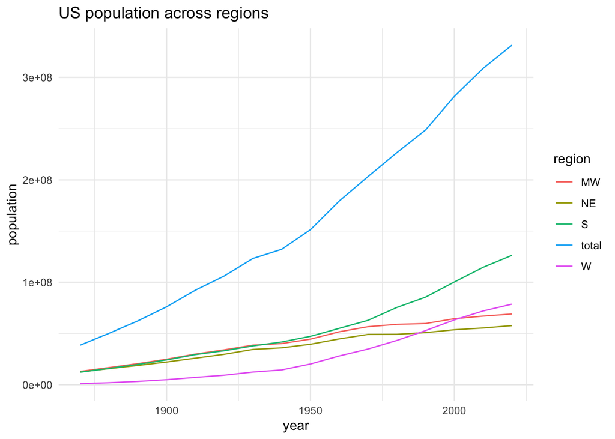

```r
## proportion/totals of USA from each region
df_long = pivot_longer(df, cols = c("NE", "MW", "S", "W", "total"),
                        names_to = "region", values_to = "population")

df_long_inter = df_long %>% group_by(region) %>%
  summarise(yearID = 1870:2020,
            pop = approx(year, population, xout = 1870:2020)$y) %>%
  group_by(yearID) %>%
  summarise(region, pop, pop_perc = pop / sum(pop) * 2)

## total population of USA across regions
ggplot(df_long_inter, aes(x = yearID, y = pop, col = region)) +
  geom_line() +
    labs(title = "US population across regions",
       y = "population",
       x = "year") +
  theme_minimal()
```

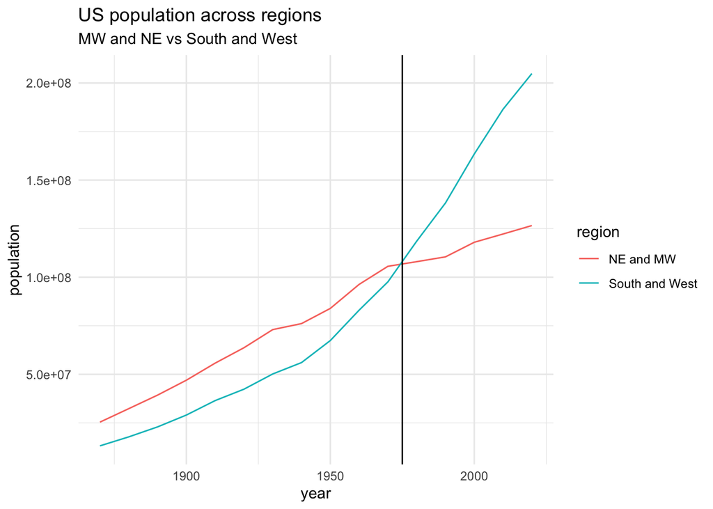

```r
## total population of USA across regions
ggplot(df_long_inter %>% filter(region != "total") %>%
         group_by(yearID) %>%
         summarise("NE and MW" = sum(pop[region %in% c("NE","MW")]),
                   "South and West" = sum(pop[region %in% c("S","W")])) %>%
         pivot_longer(cols = "NE and MW":"South and West", names_to = "region"),
       aes(x = yearID, y = value, col = region)) +
  geom_line() +
    labs(title = "US population across regions",
         subtitle = "MW and NE vs South and West",
       y = "population",
       x = "year") +
  geom_vline(xintercept = 1975) +
  theme_minimal()
```

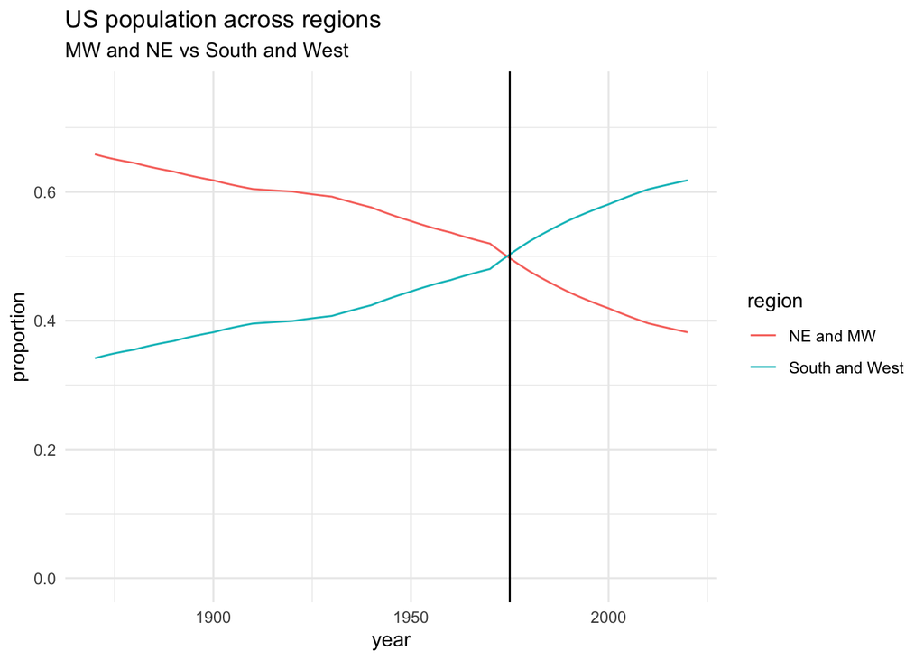

```r
## proportion of USA
ggplot(df_long_inter %>% filter(region != "total") %>%
         group_by(yearID) %>%
         summarise("NE and MW" = sum(pop_perc[region %in% c("NE","MW")]),
                   "South and West" = sum(pop_perc[region %in% c("S","W")])) %>%
         pivot_longer(cols = "NE and MW":"South and West", names_to = "region"),
       aes(x = yearID, y = value, col = region)) +
  geom_line() +
    labs(title = "US population across regions",
         subtitle = "MW and NE vs South and West",
       y = "proportion",
       x = "year") +
  geom_vline(xintercept = 1975) +
  ylim(0,0.75) +
  theme_minimal()
```

We show that a similar inflection point in the proportion of MLB representation happens in 1962. After 1962, the MLB is primarily represented by people from the South and West regions and international sources.

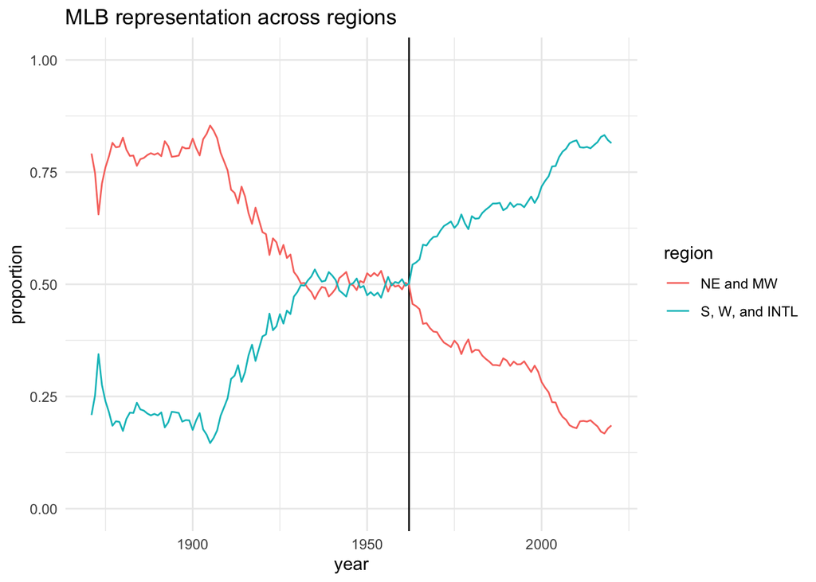

```r
region_perc_pop = region_perc %>%
  left_join(df_long_inter) %>%
  filter(yearID <= 2020) %>%
  group_by(yearID) %>%
  summarise("NEpMW_MLB" = sum(region_perc[region %in% c("NE","MW")], na.rm = TRUE),
            "SpW_MLB" = sum(region_perc[region %in% c("S","W")],
                                   na.rm = TRUE),
            "SpWpINTL_MLB" = sum(region_perc[!region %in% c("NE","MW")],
                                          na.rm = TRUE),
            "NEpMW_pop" = sum(pop[region %in% c("NE","MW")], na.rm = TRUE),
            "SpW_pop" = sum(pop[region %in% c("S","W")], na.rm = TRUE),
            "SpWpINTL_pop" = sum(pop[!region %in% c("NE","MW")], na.rm = TRUE),
            "NEpMW_pop_prop" = sum(pop_perc[region %in% c("NE","MW")], na.rm = TRUE),
            "SpW_pop_prop" = sum(pop_perc[region %in% c("S","W")], na.rm = TRUE))

region_perc_pop %>%
  rename("NE and MW" = NEpMW_MLB,
         "S, W, and INTL" = SpWpINTL_MLB) %>%
  pivot_longer(cols = c("NE and MW","S, W, and INTL"),
               names_to = "region") %>%
  ggplot() +
  aes(x = yearID, y = value, col = region) +
  geom_vline(xintercept = 1962) +
  geom_line() +
  theme_minimal() +
  labs(title = "MLB representation across regions",
       y = "proportion",
       x = "year") +
  ylim(0,1)
```

We also see that from 1871-1925, the MLB was over-represented by people from the NE and MW regions. From 1925-1962, the MLB was nearly properly represented by people from the NE and MW regions. From 1962-present, the MLB was under-represented by people from the NE and MW regions.

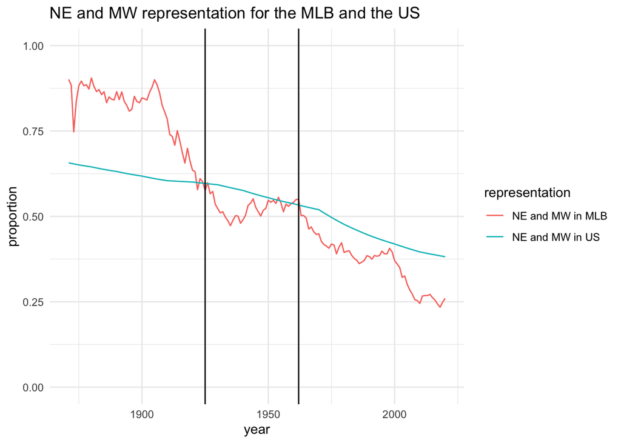

```r
region_perc_pop %>%
  mutate(NEpMW_MLB = NEpMW_MLB/(NEpMW_MLB + SpW_MLB)) %>%
  rename("NE and MW in MLB" = NEpMW_MLB,
         "NE and MW in US" = NEpMW_pop_prop) %>%
  pivot_longer(cols = c("NE and MW in MLB","NE and MW in US"),
               names_to = "representation") %>%
  ggplot() +
  aes(x = yearID, y = value, col = representation) +
  geom_line() +
  theme_minimal() +
  labs(title = "NE and MW representation for the MLB and the US",
       y = "proportion",
       x = "year") +
  geom_vline(xintercept = 1925) +
  geom_vline(xintercept = 1962) +
  ylim(0,1)
```

We now estimate the talent pool (not yet adjusted for changing level interest). The main reasons for the break point in the early 1960s are:

- The post WWII lull in the proportion of the USA that is in the talent pool and the corresponding [Baby Boom](https://en.wikipedia.org/wiki/Baby_boomers).
- The proportion of the MLB that is from the NE and MW regions start to decline as the MLB expands.

Below we calculate and plot the proportion of the US population that belongs to the talent pool (age 20-29 males). We see a pronounced post World War II drop followed by a surge corresponding to when people from the [Baby Boom generation](https://en.wikipedia.org/wiki/Baby_boomers) (born between 1946 and 1964) started coming of age to play in the MLB.

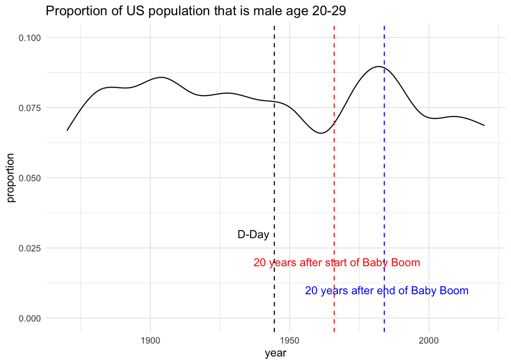

```r
prop_eligible = rbind(prop_eligible,
foo %>% left_join(df %>% dplyr::select(year, total)) %>%
  mutate(prop = pop * 1e6/total) %>%
  dplyr::select(year, prop))
# https://www.census.gov/data/tables/2020/demo/age-and-sex/2020-age-sex-composition.html
prop_eligible = rbind(prop_eligible,
                       c(2020, (10.573 + 11.682) / 325.268 ))
prop_eligible_long = data.frame(
  year = 1870:2020,
  prop_elig = approx(prop_eligible$year, prop_eligible$prop, xout = 1870:2020)$y
)

prop_eligible_long$prop_elig_smooth =
  predict(lm(prop_elig ~ ns(year, df=13), data=prop_eligible_long))
ggplot(prop_eligible_long, aes(x = year, y = prop_elig)) +
  ylim(0, 0.10) +
  geom_line(aes(x = year, y = prop_elig_smooth)) +
  labs(title = "Proportion of US population that is male age 20-29",
       y = "proportion",
       x = "year") +
  theme_minimal() +
  geom_vline(xintercept = 1944.5, lty = 2) +
  geom_vline(xintercept = 1966, lty = 2, col = "red") +
  geom_vline(xintercept = 1984, lty = 2, col = "blue") +
  annotate("text", x = c(1937,1967,1985), y = c(0.03,0.02,0.01),
           label = c("D-Day","20 years after start of Baby Boom",
                     "20 years after end of Baby Boom"),
           color = c("black","red","blue"))
```

We now multiple the population of people from the NE and MW regions by the proportion of that population that is male age 20-29. This gives us an estimate of the talent pool that is not yet adjusted for external factors.

```r
region_perc_pop_NEMW = region_perc_pop %>%
  left_join(prop_eligible_long, by = c("yearID" = "year")) %>%
  mutate(MLBeligibleNEMW = NEpMW_pop/NEpMW_MLB * prop_elig)
region_perc_pop_NEMW = region_perc_pop_NEMW[1:150, ]

region_perc_pop_NEMW %>%
  filter(yearID %in% c(1871, seq(from = 1880, to = 2020, by = 10))) %>%
  dplyr::select(yearID, MLBeligibleNEMW) %>% as.data.frame()
```

```
##    yearID MLBeligibleNEMW
## 1    1871         2259662
## 2    1880         3167278
## 3    1890         4091693
## 4    1900         4783564
## 5    1910         6320357
## 6    1920         7929134
## 7    1930        11567837
## 8    1940        12102545
## 9    1950        12296708
## 10   1960        12539318
## 11   1970        20335683
## 12   1980        28402872
## 13   1990        27805051
## 14   2000        29086696
## 15   2010        49622223
## 16   2020        46715012
```

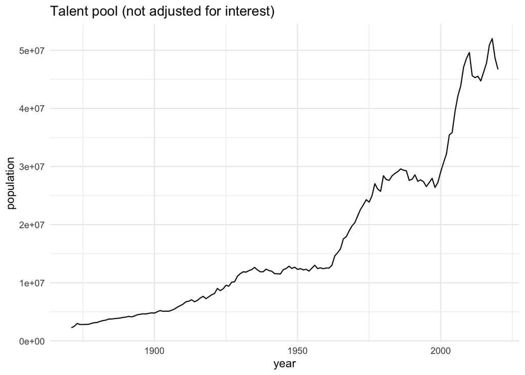

```r
ggplot(region_perc_pop_NEMW, aes(x = yearID, y = MLBeligibleNEMW)) +
  geom_line() +
  labs(title = "Talent pool (not adjusted for interest)",
       y = "population",
       x = "year") +
  theme_minimal()
```

We zoom in on the years between 1950 and 1975. We see that the proportion of the MLB that is from the NE and MW ($\texttt{NEpMW\_MLB\_prop}$) starts stable but starts to decline rapidly in the mid/late 1960s and into 1970s, and the proportion of the USA population that is an aged 20-29 male ($\texttt{prop\_elig}$) increases dramatically with increases from 1960 to 1975.

```r
region_perc_pop_NEMW %>% select(yearID, NEpMW_MLB,
                                prop_elig, MLBeligibleNEMW) %>%
  rename("NEpMW_MLB_prop" = NEpMW_MLB) %>%
  filter(yearID >= 1950, yearID <= 1975) %>%
  as.data.frame()
```

```
##    yearID NEpMW_MLB_prop  prop_elig MLBeligibleNEMW
## 1    1950      0.5245283 0.07684141        12296708
## 2    1951      0.5174954 0.07552082        12429972
## 3    1952      0.5251799 0.07420024        12208525
## 4    1953      0.5187266 0.07287965        12314050
## 5    1954      0.5298507 0.07155906        12003975
## 6    1955      0.5058431 0.07023848        12513250
## 7    1956      0.4836957 0.06891789        13016248
## 8    1957      0.5026643 0.06759731        12451253
## 9    1958      0.4948276 0.06627672        12566871
## 10   1959      0.4973730 0.06495614        12414835
## 11   1960      0.4886957 0.06363555        12539318
## 12   1961      0.5032258 0.06484700        12529119
## 13   1962      0.4985755 0.06605845        13005652
## 14   1963      0.4561151 0.06726989        14614469
## 15   1964      0.4514286 0.06848134        15173424
## 16   1965      0.4444444 0.06969279        15830576
## 17   1966      0.4117647 0.07090423        17544396
## 18   1967      0.4136490 0.07211568        17925273
## 19   1968      0.4023669 0.07332713        18907216
## 20   1969      0.3945819 0.07453858        19774755
## 21   1970      0.3934040 0.07575002        20335683
## 22   1971      0.3804348 0.07733364        21517118
## 23   1972      0.3701456 0.07891725        22619037
## 24   1973      0.3654080 0.08050087        23424695
## 25   1974      0.3600465 0.08208448        24295650
## 26   1975      0.3744076 0.08366809        23867865
```

We see that MLB representation from MW and NE declines slightly with international and the Western states improving their MLB representation over 1950-1975.

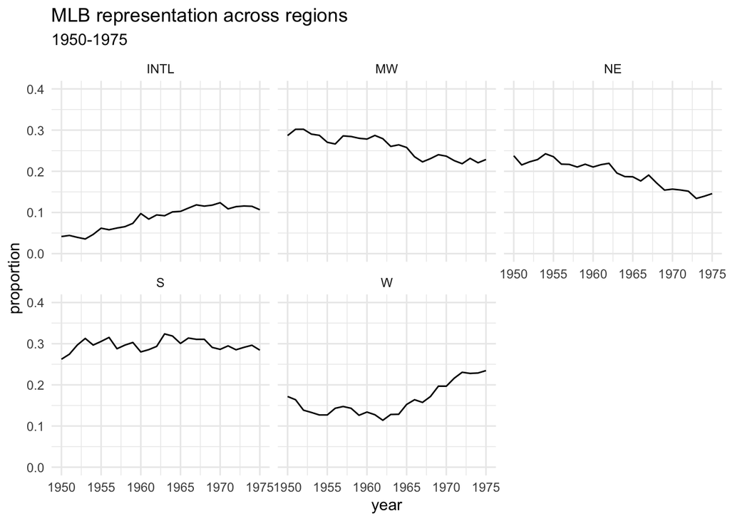

```r
## By region
ggplot(region_perc %>%
         filter(yearID >= 1950, yearID <= 1975) %>%
         filter(region %in% c("INTL", "NE", "W", "MW", "S")),
       aes(x = yearID, y = region_perc)) +
  geom_line() +
  facet_wrap(~region) +
  labs(title = "MLB representation across regions",
       subtitle = "1950-1975",
       y = "proportion",
       x = "year") +
  ylim(0,0.4) +
  theme_minimal()
```

## Adjustments

#### Interest adjustment

We will first adjust the talent pool for changes in baseball interest over time. We will use these sources:

- Gallup polling data on the question: what is your favorite sport? This survey ranges from 1937-2017. [Source](https://news.gallup.com/poll/4735/sports.aspx)
- Gallup polling data on general baseball interest stratified by age/gender. This survey was conducted in 1937, 1952, and 2001. We will use information from the “Fan or Follower of Professional/Major League Baseball?” graphic for males aged 19-29. [Source](https://news.gallup.com/poll/6745/baseball-fan-numbers-steady-decline-may-pending.aspx)
- Harris polling data on favorite sports. This survey ranges from 1985-2016. [Source 1](https://www.sportsbusinessjournal.com/Daily/Issues/2015/01/28/Research-and-Ratings/Harris-Poll.aspx) and [Source 2](https://www.businessinsider.com/most-popular-sports-in-the-us-2016-3)
- Harris polling data on the question: are you a fan or follower of this sport? [Source](https://boxingjunkie.usatoday.com/2021/06/harris-poll-boxing-more-popular-than-mma-hockey-tennis-golf)

The Harris and Gallup polling data on general baseball interest (are you a fan/follower of baseball) indicates that baseball interest has been relatively constant throughout the years, although it has deceased. However, the proportion of Americans who view baseball as their favorite sport has dramatically fallen. Note that Harris reports a higher proportion of the population whose favorite sport is baseball than Gallup. We will average the survey results. We will then define interest in baseball as the average of general baseball interest and those who consider baseball their favorite sport. This reflects the fact that some MLB players list other sports as their favorite (For example, [Tony Gwynn loved basketball before baseball](https://www.mlb.com/news/tony-gwynn-drafted-in-baseball-basketball-on-same-day)). Other aggregations will be considered in the Appendix (75% favorite sport is baseball and 25% general baseball interest; 100% favorite sport is baseball).

We could not find survey data about baseball interest prior to 1937. We will set baseball interest at 0.20, 0.20, 0.22, 0.30, and 0.38 respectively for years 1870, 1876, 1886, 1920, and 1930. We have endeavored to make reasonable choices for interest levels of young white adult males towards baseball over time, starting in the 1870s into the current era. This starting point of interest level for 1870 aims to balance the geographic area where the sport was played and increasing awareness from greater organization and media coverage of professional baseball. Indeed, our aim is looking at what conditions influence the interest of the generation of young white males that shape their fandom or even aspiration of becoming a ballplayer and how that increases and decreases over time. Thus, formation of the National League in 1876 would spur interest. So would the emergence of [Babe Ruth in 1919-1920](https://www.smithsonianmag.com/smithsonian-institution/how-babe-ruth-changed-baseball-51810018/) not only as a home-run slugger but also as the well-covered “Sultan of Swat,” a media sensation whose popularity was aided by the newsprint media.

In a certain sense, we are generous in placing the 1870 interest level among the white male population interested in baseball at 20 percent. Baseball salaries were far lower in the past, [media exposure was far less](https://www.countryliving.com/life/g33398396/what-things-cost-100-years-ago/) than it is in more modern eras, and baseball teams would [disband with some frequency in the older eras](https://sportsecyclopedia.com/toc/mlb/mlbdefunct.html). These early era realities may negatively effect one’s interest in pursuing a career in baseball. Our analysis does not make any explicit adjustments for changing salaries for MLB salaries, but it does explicitly account for increased competition from other sports. A thorough accounting for changing salaries is beyond the scope of this work, but it may have a considerable negative effect on the population pursuing a career in the MLB prior to more modern times. [As recently as 1967](https://2.files.edl.io/jA6I1n2gS1NmGe5cHmTHv0s3AzS0Y2uiXAItMJiIlsQbl2Pu.pdf), the MLB minimum salary was $6000 and the MLB average salary was $19,000 while the [median household income](https://www.census.gov/library/publications/1968/demo/p60-57.html) was $7200. In 2022 the [real median income](https://seekingalpha.com/article/4561749-median-household-income-in-october-2022) is roughly $75,000 while the [MLB minimum salary](https://www.statista.com/statistics/256187/minimum-salary-of-players-in-major-league-baseball/) is $700,000 and the [MLB average salary](https://www.espn.com/mlb/story/_/id/35748547/mlb-average-salary-rose-148-record-422m-last-season) is roughly $4,000,000. Before 1967, detailed salary data becomes sparse. [This article](https://eh.net/encyclopedia/the-economic-history-of-major-league-baseball/) reports that the average MLB salary in 1920 was $5000 which is less than double the [median household income](https://www.countryliving.com/life/g33398396/what-things-cost-100-years-ago/) at the time which was about $3300.

However, it can be said that baseball may be a source of social mobility for lower-class men even though MLB salaries were lower in the past. [Riess (1980)](https://www.jstor.org/stable/203781?casa_token=PC6lcGDSiHkAAAAA%3AqhP7vOZwkBZOX_wLXD_uSPM0Aagsj2EKrJin_RIEDcO9gaMn92rJTgZeTRdw-kduCRO4KQtEfhUZlY8JePE8Q5zYw4D0ZuIrvsAe7ZMe5YQZDndDdD6v) studied professional baseball and social mobility in the Progressive era. He concluded that professional baseball was greatly overrated as a source of upward mobility when the game was at its unchallenged height, and that MLB jobs went mostly to well-educated, middle-class native American whites, Irishmen, and Germans who utilized the sport as a means of maintaining their social status and planned to use it as a ladder to future success. In summarizing Riess’s 1980 book [*Touching Base*](https://www.amazon.com/Touching-Base-Professional-Baseball-Progressive/dp/0252067754), [Gerlach (1994)](https://www.jstor.org/stable/43609976) stated that the depiction of baseball as an “all-American game embodying all American virtues and values” was the prescriptive construct of a burgeoning baseball business geared to and supported by a native-born middle class.

It should be noted that there were more professional opportunities to play baseball in the past even though MLB salaries were lower, and that the relatively fewer professional opportunities that exist today may reflect a fundamental lack of interest in reaching the MLB that is not captured by surveys. In a study of structural mutualism–cooperative behavior among teams to the benefit of each due to the benefit of their membership in leagues–with respect to minor league baseball team and league foundings and disbandings, [Land, Davis, and Blau (1994)](https://www.journals.uchicago.edu/doi/abs/10.1086/230581) charted the density of minor leagues and minor league teams. This chart clearly revealed a dramatic decrease in minor league operations after a pronounced post-WWII peak. The number of teams (leagues) was at 448 (59) in 1949, and fell to 132 (20) in 1964 ([see here](https://www.milb.com/milb/history/general-history) for details). As noted by Land, Davis, and Blau (1994), Sullivan’s 1990 book [*The Minors*](https://www.amazon.com/s?k=9780312302214&i=stripbooks&linkCode=qs) attributed this decline in the minor leagues to relocation of MLB teams to minor league markets and the spread of television broadcasting games. [Bellamy and Walker (2004)](https://muse.jhu.edu/article/171368) noted that television went from 0.4 percent of U.S. households in 1948 to 87.1 percent in 1960. However, these authors concluded that the extension of MLB radio broadcasts, both national and local, in combination with a market correction, probably hurt the Minor Leagues, particularly in the first half of the 1950s, much more than the televised broadcasts that were in their infancy.

[Land, Davis, and Blau (1994)](https://www.journals.uchicago.edu/doi/abs/10.1086/230581) stated that: “the single most important event in the history of the minors occurred in 1920s, with the implementation of the farm system…This system allowed the Cardinals to field extremely competitive teams without having to pay high prices to the minor-league clubs that owned the player’s contracts. The New York Yankees soon adopted this strategy and dominated the AL in the 1930s. It is not clear to what extent other teams wanted, or were able, to use this system during the 1930s, but it clearly was common.” [Horowitz (1997)](https://link.springer.com/article/10.1023/A:1007799730191) studied competitive balance in the MLB and speculated that “the owners, however, solely for business purposes, embraced expansion and allowed their lust for broadcast-rights revenues to hasten the erosion of the minor leagues and their farm systems.” However, footnote 9 in [Land, Davis, and Blau (1994)](https://www.journals.uchicago.edu/doi/abs/10.1086/230581) stated that the majority of minor league teams that died were independent teams not affiliated with an MLB farm system.

In aggregate, it appears that collapse of professional baseball (proxied by the Minors) is a mere shuffling around and does not reflect some deep collapse in the talent pool. Thus, the rapid contraction of professional opportunities (proxied by the Minor Leagues) can be explained, albeit not completely, by factors (relocation of MLB teams to minor league markets, extensions of MLB radio and television broadcasts, a possible market correction, and structural mutualism) that do not necessarily signal a corresponding rapid decrease in interest in playing baseball professionally which would not be captured by surveys. Moreover, per game attendance has steadily risen over time with some peaks and valleys corresponding to historical events. That being said, in the Appendix we will consider an estimate of the talent pool in which interest in baseball is higher during the years preceding the erosion of the minor leagues.

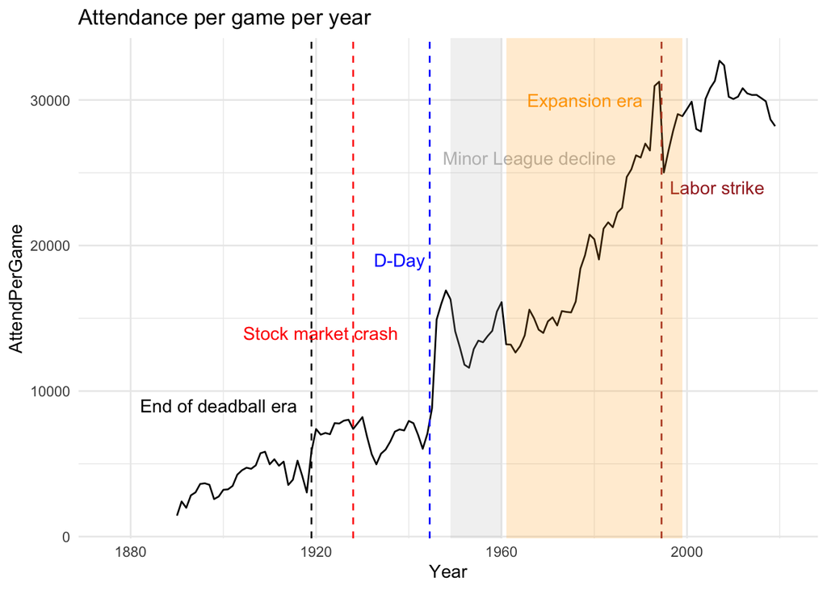

```r
MLBattendance = read_csv("MLBattendance.csv")
colnames(MLBattendance)[3] = "AttendPerGame"
MLBattendance %>%
  ggplot() +
  aes(x = Year, y = AttendPerGame) +
  geom_line() +
  theme_minimal() +
  labs(title = "Attendance per game per year") +
  geom_vline(xintercept = 1919, lty = 2) +
  geom_vline(xintercept = 1928, lty = 2, col = "red") +
  geom_vline(xintercept = 1944.5, lty = 2, col = "blue") +
  geom_vline(xintercept = 1994.5, lty = 2, col = "brown") +
  annotate("text", x = c(1899,1921,1938,1966,1978,2006.5),
           y = c(9000,14000,19000,26000,30000,24000),
           label = c("End of deadball era",
                     "Stock market crash",
                     "D-Day",
                     "Minor League decline",
                     "Expansion era",
                     "Labor strike"),
           color = c("black","red","blue", "grey", "orange","brown")) +
  annotate("rect", fill = "grey", alpha = 0.2,
        xmin = 1949, xmax = 1960,
        ymin = -Inf, ymax = Inf) +
    annotate("rect", fill = "orange", alpha = 0.2,
        xmin = 1961, xmax = 1999,
        ymin = -Inf, ymax = Inf)
```

We now add our estimate of baseball interest. We will use interpolation for missing seasons. Smoothing will be applied. This smoothing helps with jaggedness and handles the jump in interest due to switching from Gallup to the average of Gallup and Harris. Historical interest in baseball is estimated and plotted below.

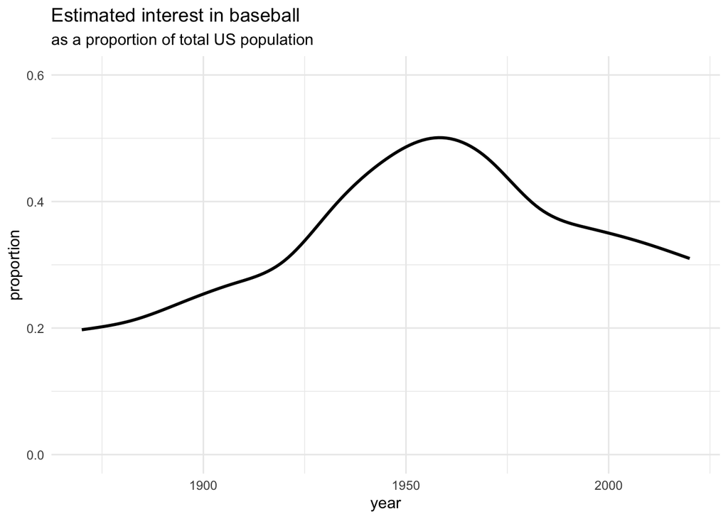

```r
## Compute interest adjustment
#https://news.gallup.com/poll/4735/sports.aspx
#https://www.mprnews.org/story/2015/05/11/is-baseball-dying-no
favorite_Gallup = data.frame(
  year = c(1937, 1948, 1960, 1972, 1981, 1990, 1994, 1998, 2000, 2001, 2002,
           2003, 2004, 2005, 2006, 2007, 2008, 2013, 2014, 2017) + 10,
  interest = c(0.34, 0.39, 0.34, 0.22, 0.16, 0.16, 0.18, 0.12, 0.13, 0.12, 0.12,
               0.10, 0.10, 0.12, 0.11, 0.13, 0.10, 0.14, 0.14, 0.09)#/2 + 0.42/2
)

#Harris poll
#https://www.sportsbusinessjournal.com/Daily/Issues/2015/01/28/Research-and-Ratings/Harris-Poll.aspx
#https://www.businessinsider.com/most-popular-sports-in-the-us-2016-3
favorite_Harris = data.frame(year = c(1985, 1989, 1992, 1998, 2009, 2010,
                                       2011, 2012, 2013, 2014, 2016) + 10,
                              interest = c(0.23, 0.19, 0.21, 0.18, 0.16, 0.17,
                                           0.13, 0.16, 0.14, 0.16, 0.15))

## Combined information
favorite = data.frame(
  year = 1947:2020,
  interest = approx(favorite_Gallup$year, favorite_Gallup$interest, xout = 1947:2020)$y
)

favorite[favorite$year >= 1995, ]$interest =
  approx(favorite_Gallup$year, favorite_Gallup$interest, xout = 1995:2020)$y / 2 +
  approx(favorite_Harris$year, favorite_Harris$interest, xout = 1995:2020)$y / 2

#https://news.gallup.com/poll/6745/baseball-fan-numbers-steady-decline-may-pending.aspx
#https://onlinemasters.ohio.edu/blog/mlb-young-fans/
#https://boxingjunkie.usatoday.com/2021/06/harris-poll-boxing-more-popular-than-mma-hockey-tennis-golf
interest = data.frame(
  year = c(1937,1952,2001,2021) + 10,
  interest = c(0.62,0.62,0.50,0.49)
)

# 50% for favorite; 50% for general interest
MLB_interest = data.frame(
year = 1947:2020,
interest = (approx(favorite$year, favorite$interest, xout = 1947:2020)$y +
              approx(interest$year, interest$interest, xout = 1947:2020,
                     rule = 2)$y)/2
)

# The existence of the MLB itself
MLB_interest = rbind(c(1870,0.20), c(1876, 0.20), c(1886, 0.22), c(1920,0.30),
                      c(1930, 0.38), MLB_interest)

dat_interest = data.frame(
  year = 1870:2020,
  interest = approx(MLB_interest$year, MLB_interest$interest, rule = 2,
                    xout = 1870:2020)$y
)

dat_interest$interest_smooth = predict(lm(interest ~ ns(year, df=12), data=dat_interest))
ggplot(dat_interest, aes(x = year, y = interest)) +
  labs(title = "Estimated interest in baseball",
       subtitle = "as a proportion of total US population",
       y = "proportion",
       x = "year") +
  geom_line(aes(x = year, y = interest_smooth), lwd = 1) +
  theme_minimal() +
  ylim(c(0,0.60))
```

We now plot the talent pool adjusted for interest.

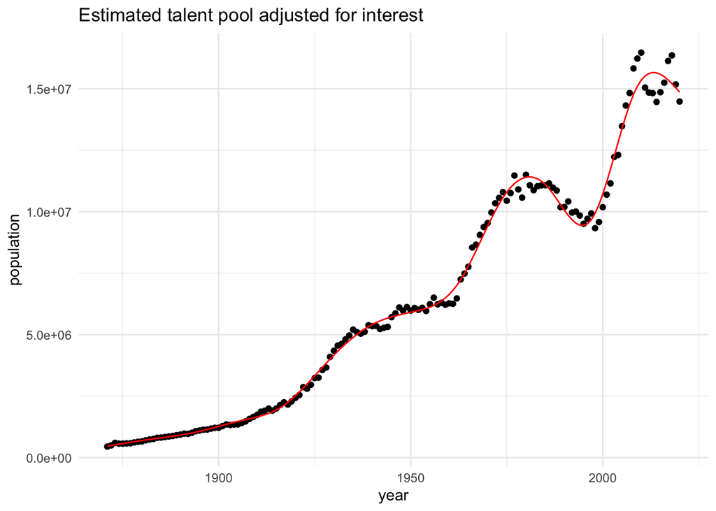

```r
region_perc_pop_NEMW = region_perc_pop %>%
  mutate(MLBeligibleNEMW = NEpMW_pop/NEpMW_MLB) %>%
  left_join(prop_eligible_long, by = c("yearID" = "year")) %>%
  left_join(dat_interest, by = c("yearID" = "year")) %>%
  mutate(MLBeligibleNEMW_adj = MLBeligibleNEMW * interest_smooth * prop_elig)
region_perc_pop_NEMW = region_perc_pop_NEMW[1:150, ]
region_perc_pop_NEMW$MLBeligibleNEMW_adj_smooth =
  round(predict(lm(MLBeligibleNEMW_adj ~ ns(yearID, df=13), data=region_perc_pop_NEMW)))

ggplot(region_perc_pop_NEMW, aes(x = yearID, y = MLBeligibleNEMW_adj)) +
  geom_point() +
  geom_line(aes(x = yearID, y = MLBeligibleNEMW_adj_smooth), color = "red") +
  labs(title = "Estimated talent pool adjusted for interest",
       y = "population",
       x = "year") +
  theme_minimal()
```

We take a closer look at the period from 1995-2010 which shows a dramatic increase in the talent pool. We see that the proportion of the population that is a member of the talent pool ($\texttt{prop\_elig}$) has a sharp decline and modest rebound over this time period. Interest in baseball exhibits a modest decrease over these years. The main driver of this massive increase in the talent pool is due to the percentage of baseball players from the NE and MW region decreasing over this time period.

```r
region_perc_pop_NEMW %>% dplyr::select(yearID, NEpMW_MLB, prop_elig, MLBeligibleNEMW_adj_smooth, interest) %>%
  filter(yearID >= 1995, yearID <= 2010) %>%
  as.data.frame()
```

```
##    yearID NEpMW_MLB  prop_elig MLBeligibleNEMW_adj_smooth  interest
## 1    1995 0.3283319 0.07631334                    9441303 0.3670918
## 2    1996 0.3163891 0.07496025                    9508936 0.3633673
## 3    1997 0.3045414 0.07360717                    9669798 0.3596429
## 4    1998 0.3187184 0.07225408                    9932647 0.3559184
## 5    1999 0.3052109 0.07090099                   10286647 0.3521939
## 6    2000 0.2821138 0.06954790                   10714803 0.3526361
## 7    2001 0.2696721 0.06987314                   11200119 0.3543282
## 8    2002 0.2594417 0.07019839                   11725596 0.3560204
## 9    2003 0.2373984 0.07052363                   12274237 0.3547959
## 10   2004 0.2365678 0.07084888                   12829045 0.3535714
## 11   2005 0.2166532 0.07117412                   13373022 0.3473469
## 12   2006 0.2045089 0.07149936                   13889171 0.3411224
## 13   2007 0.1979656 0.07182461                   14360495 0.3348980
## 14   2008 0.1859024 0.07214985                   14769995 0.3286735
## 15   2009 0.1816746 0.07247509                   15101080 0.3282444
## 16   2010 0.1793435 0.07280034                   15348375 0.3278154
```

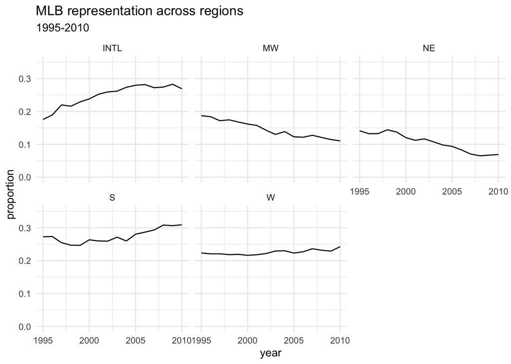

```r
ggplot(region_perc %>%
         filter(yearID >= 1995, yearID <= 2010) %>%
         filter(region %in% c("INTL", "NE", "S", "MW", "W")),
       aes(x = yearID, y = region_perc)) +
  geom_line() +
  facet_wrap(~region) +
  ylim(c(0, 0.35)) +
    labs(title = "MLB representation across regions",
       subtitle = "1995-2010",
       y = "proportion",
       x = "year") +
  theme_minimal()
```

It is worth noting that [MLB expansion and team relocations](https://en.wikipedia.org/wiki/Timeline_of_Major_League_Baseball) that happened from 1970 to 1998:

- 1969-1970: Seattle Pilots created, fold, and move to Milwaukee to become the Brewers.
- 1970: The Washington Senators move to Arlington, Texas, in the Dallas–Fort Worth metroplex and become the Texas Rangers.
- 1977: The Seattle Mariners are enfranchised and are placed in the AL West.
- 1977: The Toronto Blue Jays are enfranchised and are placed in the AL East.
- 1993: The Colorado Rockies are enfranchised and are placed in the NL West.
- 1993: The Florida Marlins are enfranchised and are placed in the NL East.
- 1998: The Arizona Diamondbacks are enfranchised and are placed in the NL West.
- 1998: The Tampa Bay Devil Rays are enfranchised and are placed in the AL East.

We look at a few states over this time period. Interestingly, we find that the proportion of MLB players from California declines with New York over this time frame. Florida has a modest U-shaped proportion of MLB players from the state. Both Texas and Washington have increases over this time period.

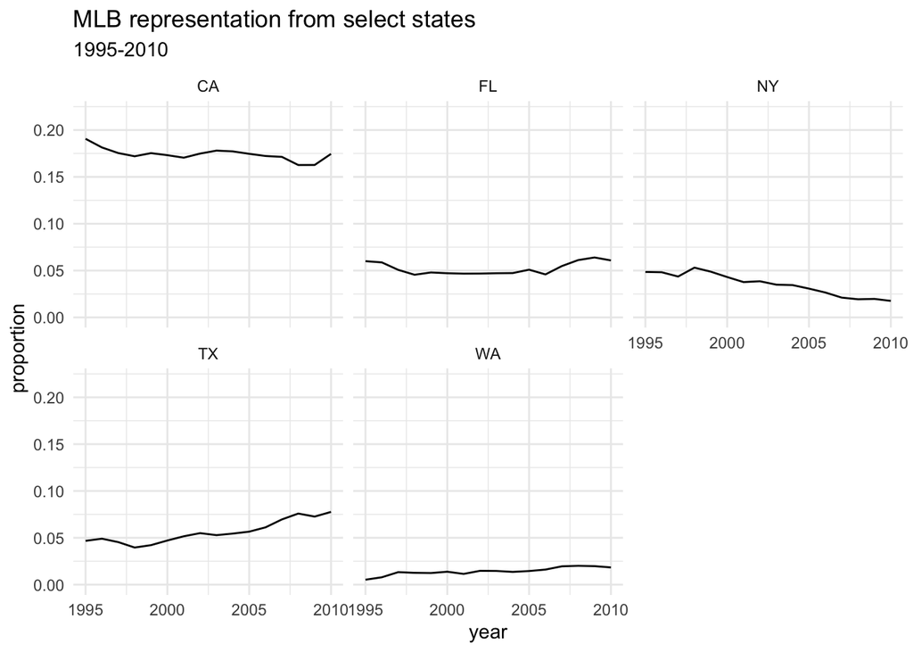

```r
ggplot(state_perc %>%
         filter(yearID >= 1995, yearID <= 2010) %>%
         filter(birthState %in% c("FL", "CA", "NY", "TX", "WA")),
       aes(x = yearID, y = state_perc)) +
  geom_line() +
  ylim(c(0,0.22)) +
  facet_wrap(~birthState) +
  labs(title = "MLB representation from select states",
       subtitle = "1995-2010",
       y = "proportion",
       x = "year") +
  theme_minimal()
```

Interestingly, the Florida increase extends into 2020 while Texas slides, New York rebounds, and California levels off.

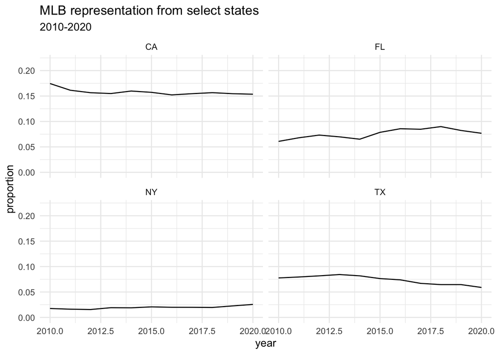

```r
ggplot(state_perc %>%
         filter(yearID >= 2010, yearID <= 2020) %>%
         filter(birthState %in% c("FL", "CA", "NY", "TX")),
       aes(x = yearID, y = state_perc)) +
  geom_line() +
  ylim(c(0,0.22)) +
  facet_wrap(~birthState) +
  labs(title = "MLB representation from select states",
       subtitle = "2010-2020",
       y = "proportion",
       x = "year") +
  theme_minimal()
```

Overall, the proportion of MLB players from different regions stabilizes from 2010-2020.

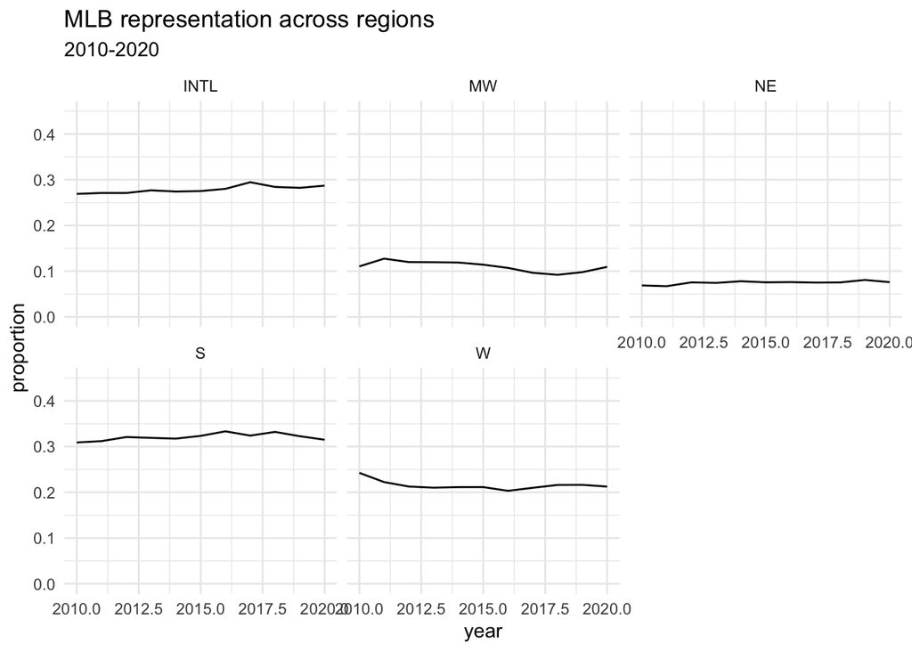

```r
## By region
ggplot(region_perc %>%
         filter(yearID >= 2010, yearID <= 2020) %>%
         filter(region %in% c("INTL", "NE", "S", "MW", "W")),
       aes(x = yearID, y = region_perc)) +
  geom_line() +
  facet_wrap(~region) +
  ylim(c(0, 0.45)) +
  labs(title = "MLB representation across regions",
       subtitle = "2010-2020",
       y = "proportion",
       x = "year") +
  theme_minimal()
```

#### War adjustments

We now create a smaller data set that contains the talent pool at each year.

```r
datMLBeligible = data.frame(
  year = region_perc_pop_NEMW$yearID,
  pop = region_perc_pop_NEMW$MLBeligibleNEMW_adj_smooth
)
```

We now adjust for the effects of wars (WWI, WWII, and Korean War). For WWI military service was minimal so we consider an interest level of 0.85 for the talent pool for years 1918 and 1919.

```r
# WWI
datMLBeligible[datMLBeligible[, 1] %in% c(1918:1919), ]$pop =
  datMLBeligible[datMLBeligible[, 1] %in% c(1918:1919), ]$pop * c(0.85,0.85)
```

[This article](https://www.usatoday.com/story/sports/2013/07/01/for-these-boys-of-summer-no-regrets/2480461/) states that roughly 100 MLB players served in the Korean War. We’ll use 0.85 as the interest level for both 1952 and 1953. We will also ignore a lingering talent drain due to the Korean War because military service was not nearly on Americans’ minds as it was in WWII.

```r
# Korean WAR
datMLBeligible[datMLBeligible[, 1] %in% c(1952:1953), ]$pop =
  datMLBeligible[datMLBeligible[, 1] %in% c(1952:1953), ]$pop *
  c(0.85,0.85)
```

We make an extensive and detailed adjustment for WWII following [Gary Bedingfield’s timeline](https://www.baseballinwartime.com/timeline/timeline_1942.htm). The steps we followed were to count the proportion of players who were active MLB players the year before they served. If a player did not have any post war stats and no credible case of returning to the MLB then they were removed from the MLB for one season. Players like Bobby Thomson who served in WWII but returned in their age 22 or younger season were not counted as MLB players who missed time due to WWII. This timeline says 7 and 18 MLB players served in WWII in 1941 and 1942, respectively. Unfortunately, Gary Bedingfield’s timeline stops in 1942. Afterwards, Gary states that there were 195, 340, and 384 MLB players serving in WWII in, respectively, 1943, 1944, and 1945. However, his count seems to include people who played in the MLB and retired or those that would go on to play in the MLB in addition to active MLB players who left the league for service in WWII. So we will calculate the number of people who only played in the MLB from 1943-1946 as a proxy for the number of people serving in the MLB during the WWII years using the $\texttt{People}$ data set in the $\texttt{Lahman}$ package. This approach yielded 90, 166, and 170 MLB players serving in WWII in, respectively, 1943, 1944, and 1945. The roster size was set at 25 players in 1941-1944 (400 total spots) and 30 players in 1945 (480 total spots). We then incorporate a two-year lingering effect to the talent pool in which we use the 1943 interest level for 1946 and the 1942 interest level for 1947. This gives interest levels from 1941-1947: 0.983 0.96 0.78 0.59 0.65 0.78 0.96.

```r
# WWII
datMLBeligible[datMLBeligible[, 1] %in% c(1941:1947), ]$pop =
  datMLBeligible[datMLBeligible[, 1] %in% c(1941:1947), ]$pop *
  (1- (c(7,18,90,166,170,90,18) / c(400,400,400,400,480,400,400)))
datMLBeligible$pop = round(datMLBeligible$pop)
```

We display the talent pool adjusted for baseball interest and wars.

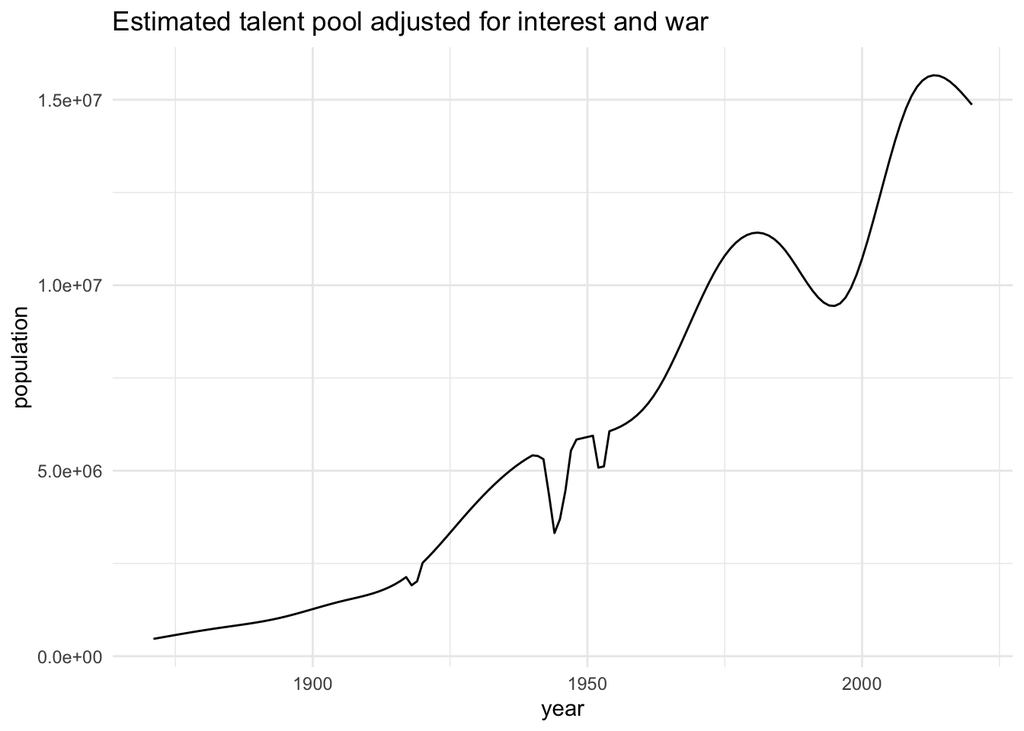

```r
ggplot(datMLBeligible, aes(x = year, y = pop)) +
  geom_line() +
  labs(title = "Estimated talent pool adjusted for interest and war",
       y = "population",
       x = "year") +
  theme_minimal()
```

#### Integration of NL and AL

$$\text{AL integration adjustment} = \frac{\% \text{white win shares in
NL}}{\% \text{white win shares in AL}},$$
where win shares is a metric developed by Bill James which allocates team wins to individual players (as stated in [Armour (2007)](https://sabr.org/journal/article/the-effects-of-integration-1947-1986/)), and percentage white win shares is the percentage of total win shares from the white players. The values for this adjustment are taken from Figures 5 and 7 in [Armour (2007)](https://sabr.org/journal/article/the-effects-of-integration-1947-1986/). We will assume that the leagues are both equally integrated when the gap in percentage white win shares closes in 1973.

```r
## Figure 5
foo = approx(x = c(1947, 1960, 1965, 1972, 1986),
       y = c(1, 0.90, 0.80, 0.70, 0.70),
       xout = 1947:1974)
## Figure 7
bar = approx(x = c(1947, 1950, 1954, 1959, 1968, 1973, 1974),
       y = c(0, 0.05, 0.05, 0.17, 0.16, 0.01, 0),
       xout = 1947:1974)
integration_adjustment = data.frame(
  year = foo$x, adjustment = (foo$y - bar$y)/foo$y )

datMLBeligible$ALpop = datMLBeligible$pop
datMLBeligible[datMLBeligible$year %in% 1947:1974, ]$ALpop =
  round(datMLBeligible[datMLBeligible$year %in% 1947:1974, ]$ALpop *
  integration_adjustment$adjustment)
```

We now depict our estimated talent pool for the NL (blue line) and the AL (red line).

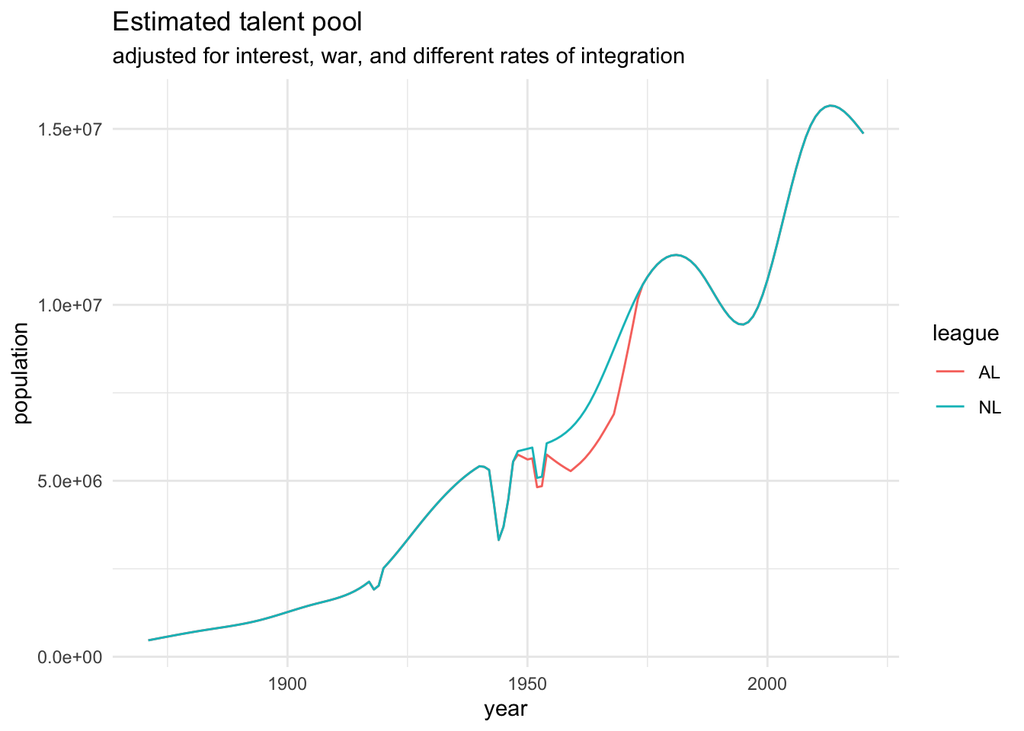

```r
ggplot(datMLBeligible %>%
         rename(NL = pop, AL = ALpop) %>%
         pivot_longer(cols = NL:AL, names_to = "league"),
       aes(x = year, y = value, color = league)) +
  geom_line() +
  labs(title = "Estimated talent pool",
       subtitle = "adjusted for interest, war, and different rates of integration",
       y = "population") +
  theme_minimal()
```

We overlay our estimated MLB population with key historical events.

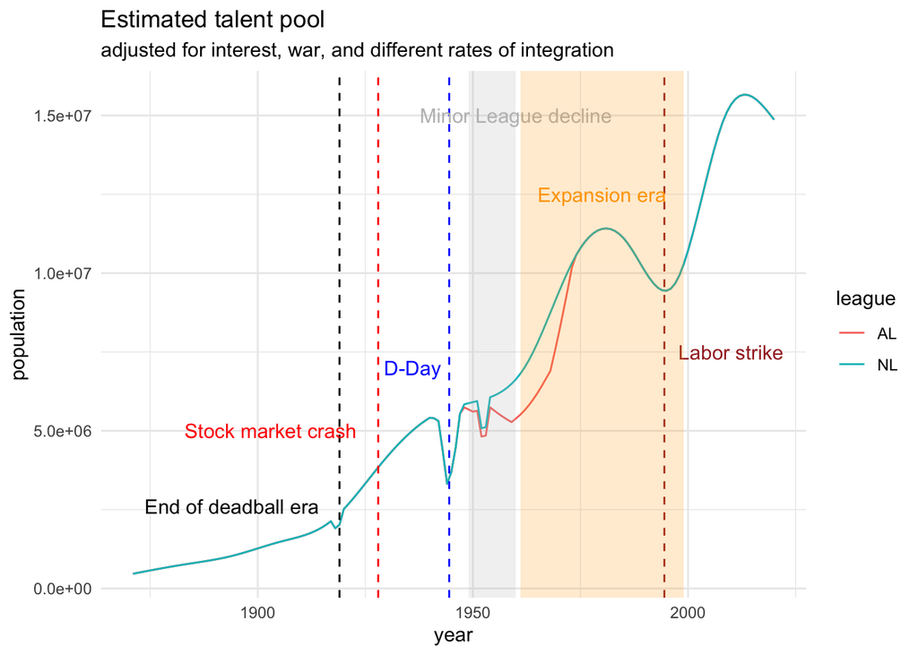

```r
ggplot(datMLBeligible %>%
         rename(NL = pop, AL = ALpop) %>%
         pivot_longer(cols = NL:AL, names_to = "league"),
       aes(x = year, y = value, color = league)) +
  geom_line() +
  labs(title = "Estimated talent pool",
       subtitle = "adjusted for interest, war, and different rates of integration",
       y = "population") +
  geom_vline(xintercept = 1919, lty = 2) +
  geom_vline(xintercept = 1928, lty = 2, col = "red") +
  geom_vline(xintercept = 1944.5, lty = 2, col = "blue") +
  geom_vline(xintercept = 1994.5, lty = 2, col = "brown") +
  annotate("text", x = c(1894,1903,1936,1960,1980,2010),
           y = c(2.6e6,5e6,7e6,1.5e7,1.25e7,7.5e6),
           label = c("End of deadball era",
                     "Stock market crash",
                     "D-Day",
                     "Minor League decline",
                     "Expansion era",
                     "Labor strike"),
           color = c("black","red","blue", "grey", "orange","brown")) +
  annotate("rect", fill = "grey", alpha = 0.2,
        xmin = 1949, xmax = 1960,
        ymin = -Inf, ymax = Inf) +
    annotate("rect", fill = "orange", alpha = 0.2,
        xmin = 1961, xmax = 1999,
        ymin = -Inf, ymax = Inf) +
  theme_minimal()
```

The code below (not run) saves our estimates of the MLB talent pool and baseball interest to disk. The $\texttt{0.5\_favorite\_sport}$ part of the file name refers to our estimate of baseball interest to be 50% from surveys of people listing baseball as their favorite sport, and 50% from surveys of general interest in baseball. In the next section, we will show that this estimate of baseball interest yields an estimate of the talent pool that aligns with an interest-adjusted estimate of the talent pool from a combination of baseball-playing Latin American countries.

```r
#write_csv(datMLBeligible, "datMLBeligible_0.5_favorite_sport.csv")
#write_csv(dat_interest, "dat_interest_favorite_0.5_sport.csv")
```

## Closer look at Dominican Republic, Venezuela, and Puerto Rico

We now investigate whether our estimated talent pool aligns with the baseball interest adjusted talent pools of Dominican Republic, Venezuela, and Puerto Rico, the three countries that immediately trail US in total MLB players and are known to have a rich history of baseball.

```r
foo_tot %>% pull(birthCountry) %>% table() %>% sort(., decreasing = TRUE) %>% head(4)
```

```
## .
##       USA      D.R. Venezuela      P.R.
##     90088      4671      2551      1932
```

It is [claimed](https://static1.squarespace.com/static/5914832ae58c629214e9fed7/t/591c9b62f5e231ade75a7ad8/1495047010650/Fun+Facts.pdf) that over 800,000 children in Dominican Republic play baseball (linked source published after 2010). We see that the number of age 5-14 male children in Dominican Republic is roughly 1 million.

```r
## number of age 5-14 male children in DR (in thousands)
WPP = read_csv("WPP_UN.csv")
WPP %>%
  filter(Date == 2010, Region == "Dominican Republic") %>%
  dplyr::select(`5-9`, `10-14`) %>%
  sum()
```

```
## [1] 1030.24
```

The [Little League Baseball in Venezuela website](http://www.zonalatina.com/Zldata134.htm) contains survey data for baseball interest in Venezuela and in Latin America (detailed survey information published in 1998). According to this website, 74% of the boys said that they like to play baseball compared to 36% of girls. This reference has a breakdown by socio-economic status: 52% and 60% of Venezuelan kids in the top 10% of income liked to play and watch baseball respectively while those numbers increase to 67% and 73% for the poorest kids in the bottom 40% of income.

```r
# https://egrove.olemiss.edu/cgi/viewcontent.cgi?article=1750&context=hon_thesis
# Wasch (2009) study
# https://static1.squarespace.com/static/5914832ae58c629214e9fed7/t/591c9b62f5e231ade75a7ad8/1495047010650/Fun+Facts.pdf
# https://www.godominicanrepublic.com/
# Over 800,000 children play organized baseball in DR
population_data$region = recode_factor(
  population_data$region, "Dominican Republic" = "DR")
foo = population_data %>% filter(region %in% c("DR")) %>%
  mutate(pop = pop * 0.95)
#https://www.worldometers.info/world-population/dominican-republic-population/
# DR population in 2022 divided by DR population in 2010
# population estimate taken January 16, 2023
foo[8, 1] = foo[7, 1]; foo[8, 2:3] = c(2022, foo[7,3] * 11.12 / 9.7)
bar = spread(foo, region, pop)
baz = approx(x = bar$year, y = bar$DR, xout = 1950:2022, n = 71)
datDR = data.frame(year = baz$x, pop = baz$y)

population_data$region = recode_factor(
  population_data$region, "Venezuela (Bolivarian Republic of)" = "Ven")
foo = population_data %>% filter(region %in% c("Ven"))
#https://www.worldometers.info/world-population/venezuela-population/
# Ven population in 2022 divided by Ven population in 2010
# population estimate taken January 16, 2023
foo[8, 1] = foo[7, 1]; foo[8, 2:3] = c(2022, foo[7,3] * 28.232 / 28.44)
bar = spread(foo, region, pop)
baz = approx(x = bar$year, y = bar$Ven, xout = 1950:2022)
datVen = data.frame(year = baz$x, pop = baz$y)
# http://www.zonalatina.com/Zldata134.htm
# 1998: 74% of boys play baseball; 71% watch baseball
# most popular among poorest kids (liked to play baseball: top 10%: 52%; bottom 40%: 67%)
datVen[datVen$year >= 1967, 2] = 0.75 * datVen[datVen$year >= 1967, 2]
datVen[datVen$year < 1967, 2] = 0.40 * datVen[datVen$year < 1967, 2]

population_data$region = recode_factor(
  population_data$region, "Puerto Rico" = "PR")
foo = population_data %>% filter(region %in% c("PR"))
#https://www.worldometers.info/world-population/puerto-rico-population/
# Puerto Rico population in 2022 divided by PR population in 2010
# population estimate taken March 01, 2024
foo[8, 1] = foo[7, 1]; foo[8, 2:3] = c(2022, foo[7,3] * 3.252 / 3.72)
bar = spread(foo, region, pop)
baz = approx(x = bar$year, y = bar$PR, xout = 1950:2022)
datPR = data.frame(year = baz$x, pop = baz$y)
# http://www.zonalatina.com/Zldata134.htm
# 1998: 74% of boys play baseball; 71% watch baseball
# most popular among poorest kids (liked to play baseball: top 10%: 52%; bottom 40%: 67%)
datPR[, 2] = 0.825 * datPR[, 2]
```

We now plot the baseball-interested adjusted population from Dominican Republic and Venezuela (red line) and the talent pool multiplied by the percentage of representation from these two countries (blue line). We note that these two quantities are in general agreement after the rapid influx of talent from these two countries leveled off.

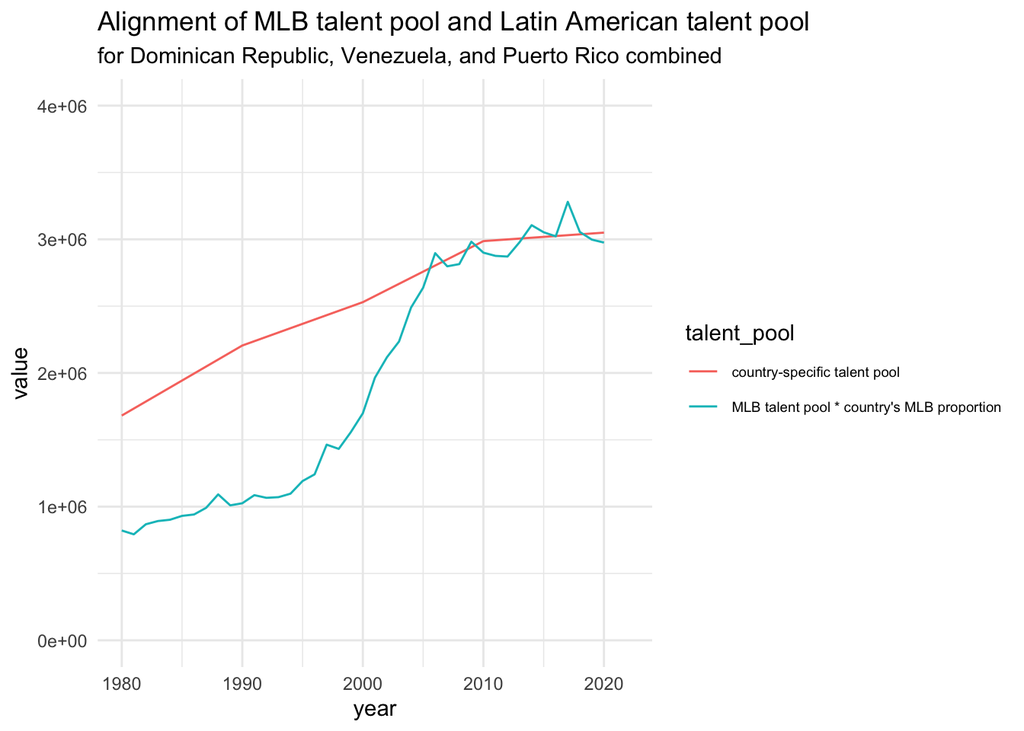

```r
## DR and Venezuela and PR
datLA = data.frame(
  year = datDR$year,
  pop = datDR$pop + datVen$pop + datPR$pop
) %>% filter(year >= 1980)

bazcombined = datMLBeligible %>% filter(year >= 1980)
bazcombined$perc_MLB_LA =
  foo_tot %>% group_by(yearID) %>%
  summarise(perc_MLB_LA =
              sum(ifelse(birthCountry %in% c("D.R.", "Venezuela", "P.R."),1,0))/n()) %>%
  filter(yearID >= 1980, yearID <= 2020) %>% pull(perc_MLB_LA)

bazcombined = bazcombined %>% mutate(pop_MLB_LA = pop*perc_MLB_LA) %>%
  dplyr::select(-pop)
bazcombined$LApop_interest = datLA %>% filter(year <= 2020) %>% pull(pop) * 1e6

ggplot(bazcombined %>%
         rename("country-specific talent pool" = LApop_interest,
                "MLB talent pool * country's MLB proportion" = pop_MLB_LA) %>%
         pivot_longer(cols = c("country-specific talent pool",
                               "MLB talent pool * country's MLB proportion"),
                      names_to = "talent_pool")) +
  aes(x = year, y = value, color = talent_pool) +
  geom_line() +
  ylim(0,4e6) +
  labs(title = "Alignment of MLB talent pool and Latin American talent pool",
       subtitle = "for Dominican Republic, Venezuela, and Puerto Rico combined",
       ylab = "population") +
  theme_minimal() +
  theme(legend.text = element_text(size = 7)) +
  scale_x_continuous(expand = expansion(mult = c(0.05, 0.1)))
```

Separately, Dominican Republic exhibits over-representation in the MLB while Venezuela exhibits under-representation (see below). Both of these findings are pronounced but are hardly surprising considering the [extensive development of baseball academies](https://sabr.org/journal/article/the-path-to-the-sugar-mill-or-the-path-to-millions-mlb-baseball-academies-effect-on-the-dominican-republic/) in Dominican Republic and Puerto Rico and the relations between USA and Venezuela ([Reuters (2019)](https://www.reuters.com/article/us-venezuela-politics-baseball/mlb-suspends-involvement-in-venezuelan-baseball-following-sanctions-idUSKCN1VC2HK), [AP News (2019)](https://apnews.com/article/venezuela-caribbean-detroit-tigers-mlb-baseball-0d869edcece74cd7a0365dcf430c3c89), [Reuters (2012)](https://www.reuters.com/article/us-baseball-venezuela/venezuela-baseball-in-limbo-due-to-mlb-fatigued-list-idUSBRE89112V20121002), and [ESPN (2007)](https://www.espn.com/mlb/news/story?id=3077371)). There is also over-representation in Puerto Rico, but this over-representation is not consequential given its magnitude. Assuming that the under-representation in Venezuela cancels with the over-representation of Dominican Republic and Puerto Rico in the MLB cancels for reasons not due to mismeasured interest or country-specific talent differences, then our construction of the talent pool is in balance with the interest-adjusted talent pool from Dominican Republic and Venezuela after the influx of MLB talent from those countries is fully realized. This supports our definition of the talent pool and our adjustments, particularly our adjustment for changing baseball interest.

```r
## DR
bazDR = datMLBeligible %>% filter(year >= 1980)
bazDR$perc_MLB_DR =
  foo_tot %>% group_by(yearID) %>%
  summarise(perc_MLB_DR =
              sum(ifelse(birthCountry %in% c("D.R."),1,0))/n()) %>%
  filter(yearID >= 1980, yearID <= 2020) %>% pull(perc_MLB_DR)

bazDR = bazDR %>% mutate(pop_MLB_DR = pop*perc_MLB_DR) %>%
  dplyr::select(-pop)
bazDR$DRpop_interest = datDR %>% filter(year >= 1980,year <= 2020) %>%
  pull(pop) * 1e6

## Ven
bazVen = datMLBeligible %>% filter(year >= 1980)
bazVen$perc_MLB_Ven =
  foo_tot %>% group_by(yearID) %>%
  summarise(perc_MLB_Ven =
              sum(ifelse(birthCountry %in% c("Venezuela"),1,0))/n()) %>%
  filter(yearID >= 1980, yearID <= 2020) %>% pull(perc_MLB_Ven)

bazVen = bazVen %>% mutate(pop_MLB_Ven = pop*perc_MLB_Ven) %>%
  dplyr::select(-pop)
bazVen$Venpop_interest = datVen %>% filter(year >= 1980, year <= 2020) %>%
  pull(pop) * 1e6

## PR
bazPR = datMLBeligible %>% filter(year >= 1980)
bazPR$perc_MLB_PR =
  foo_tot %>% group_by(yearID) %>%
  summarise(perc_MLB_PR =
              sum(ifelse(birthCountry %in% c("P.R."),1,0))/n()) %>%
  filter(yearID >= 1980, yearID <= 2020) %>% pull(perc_MLB_PR)

bazPR = bazPR %>% mutate(pop_MLB_PR = pop*perc_MLB_PR) %>%
  dplyr::select(-pop)
bazPR$PRpop_interest = datPR %>% filter(year >= 1980, year <= 2020) %>%
  pull(pop) * 1e6
```

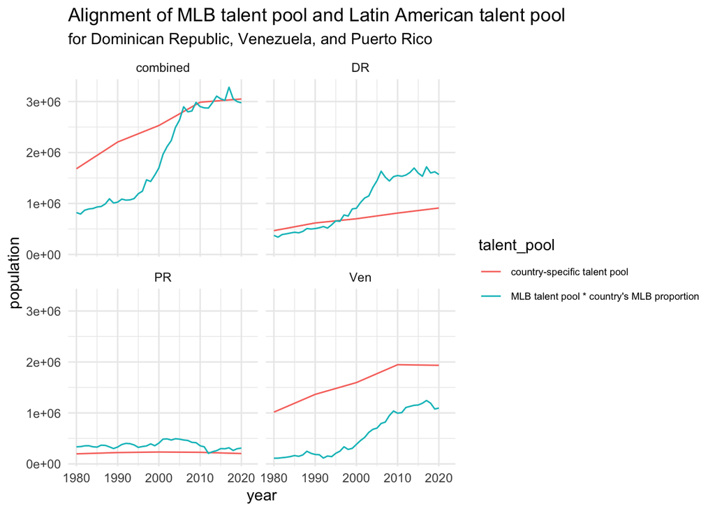

```r
rbind(
  bazcombined %>% select(year, pop_MLB_LA, LApop_interest) %>%
    rename("MLB talent pool * country's MLB proportion" = pop_MLB_LA, "country-specific talent pool" = LApop_interest) %>%
    mutate(region = "combined"),
  bazDR %>% select(year, pop_MLB_DR, DRpop_interest) %>%
    rename("MLB talent pool * country's MLB proportion" = pop_MLB_DR, "country-specific talent pool" = DRpop_interest) %>%
    mutate(region = "DR"),
  bazVen %>% select(year, pop_MLB_Ven, Venpop_interest) %>%
    rename("MLB talent pool * country's MLB proportion" = pop_MLB_Ven, "country-specific talent pool" = Venpop_interest) %>%
    mutate(region = "Ven"),
  bazPR %>% select(year, pop_MLB_PR, PRpop_interest) %>%
    rename("MLB talent pool * country's MLB proportion" = pop_MLB_PR, "country-specific talent pool" = PRpop_interest) %>%
    mutate(region = "PR")
) %>%
  pivot_longer(cols = "MLB talent pool * country's MLB proportion":"country-specific talent pool", names_to = "talent_pool") %>%
  ggplot() +
  aes(x = year, y = value, color = talent_pool) +
  geom_line() +
  facet_wrap(~region) +
  theme_minimal() +
  labs(title = "Alignment of MLB talent pool and Latin American talent pool",
       subtitle = "for Dominican Republic, Venezuela, and Puerto Rico",
       y = "population",
       x = "year") +
  theme(legend.text = element_text(size = 7)) +
  scale_x_continuous(expand = expansion(mult = c(0.05, 0.1)))
```

This analysis is focused on our estimate of the MLB talent pool immediately before, during, and after a large influx of MLB players came from abroad, particularly from Latin American countries. In this analysis we focused on MLB players from Dominican Republic, Venezuela, and Puerto Rico. These three countries comprise nearly 90% of all MLB players from Latin America, excluding Cuba and Mexico. Mexico and Cuba are be excluded because baseball interest in these countries does not translate well to MLB players due to exogenous factors. [US has an embargo on Cuba](https://en.wikipedia.org/wiki/United_States_embargo_against_Cuba), and the Mexican Baseball League, the largest of two professional baseball leagues in Mexico, [had controlled the contracts of its players](https://www.azcentral.com/story/news/politics/immigration/2019/03/28/why-so-few-major-league-baseball-players-mexico-arizona-diamondbacks/3278995002/). The linked article about the Mexican Baseball League goes on to say that “teams often charged exorbitant fees, as much as 75 percent of a player’s signing bonus, to release players,” and that “players could only play in Major League Baseball if the team allowed them to leave, and that led to those teams demanding sometimes what was perceived as exorbitant fees from major-league teams in order to get that Mexican talent.”

```r
foo_tot %>% pull(birthCountry) %>% table() %>% sort(., decreasing = TRUE)
```

```
## .
##            USA           D.R.      Venezuela           P.R.           Cuba
##          90088           4671           2551           1932           1233
##            CAN         Mexico         Panama          Japan        Ireland
##           1120            789            408            316            213
## United Kingdom        Germany       Colombia      Australia    South Korea
##            209            189            160            159            125
##        Curacao      Nicaragua           V.I.    Netherlands         Taiwan
##            113            109             95             64             64
##        missing        Jamaica          Aruba         France        Bahamas
##             56             47             40             29             28
##         Norway          Italy         Poland         Russia         Brazil
##             28             26             26             26             25
##       Slovakia Czech Republic         Sweden       Honduras        England
##             24             23             14             13             12
##       Viet Nam   Saudi Arabia    Switzerland          Spain        Austria
##             11             10             10              9              8
## American Samoa        Denmark           Guam      Hong Kong        Belgium
##              7              7              7              7              5
##           Peru    Philippines   South Africa      Lithuania      Singapore
##              5              5              5              4              4
##    Afghanistan         Belize      Indonesia        Ukriane        Bohemia
##              3              3              3              3              2
##       Portugal Atlantic Ocean          China        Finland         Greece
##              2              1              1              1              1
##         Latvia
##              1
```

```r
## populations of DR, Ven, and PR
pops_LA3 = c(4516, 2457, 1903)

## Latin American MLB population totals
##
## included countries are:
# D.R.
# Venezuela
# P.R.
# Panama
# Colombia
# Curacao
# Nicaragua
# V.I.
# Jamaica
# Aruba
# Bahamas
# Brazil
# Honduras
# Guam
# Peru
# Belize
pops_LA = c(4516, 2457, 1903, 397, 146, 108, 107, 95, 47,
            38, 27, 23, 12, 6, 4, 3)

## proportion of Latin American MLB players from
## DR, Ven, and PR, excluding Cuba and Mexico
sum(pops_LA3) / sum(pops_LA)
```

```
## [1] 0.8975629
```

Dominican Republic, Venezuela, and Puerto Rico still comprise nearly 75% of all MLB players from Latin America even with Cuba and Mexico included.

```r
pops_LA = c(4516, 2457, 1903, 1206, 770, 397, 146, 108,
            107, 95, 47, 38, 27, 23, 12, 6, 4, 3)

## proportion of Latin American MLB players from
## DR, Ven, and PR, including Cuba and Mexico
sum(pops_LA3) / sum(pops_LA)
```

```
## [1] 0.7480826
```

## Concluding remarks

Pursuit of fairness in gauging the talent pool for different eras has involved connecting the population data and the history of the major sports in the United States. First there is baseball’s geographic spread out of the North East and Midwest regions. This spread led to the sport’s increasing organization as local clubs, state associations, and “national” leagues were formed. Another variables that factored into how we gauge the player eligible population is the pace of globalization of baseball’s talent pool, and different rates of integration in the NL and AL. We adjusted our estimate of the talent pool to account for competition for athletic talent that baseball faced from other sports. Short term contractions of the talent pool due to wars were also accounted for.

## Appendix

We consider an estimate of the talent pool at different levels of baseball interest. Note that our estimate above sets baseball interest as 50% from surveys of people listing their favorite sport and 50% from general baseball interest. Here we consider:

- 75% from surveys of people listing their favorite sport and 25% from general baseball interest.
- 100% from surveys of people listing their favorite sport and 0% from general baseball interest.

These estimates of the talent pool do not align with the interest-adjust eligible populations of Latin American countries when combined. We will also consider estimates of the talent pool such that:

- The talent pool is constant throughout time (1 million people).
- The talent pool contracts sharply following the erosion of the minor leagues. For this estimate, we will suppose that baseball interest is at 90% for every season up to 1949 (the peak of the minor leagues in terms of number of leagues and teams) and will decrease to the interest level in our original analysis in 1964 (the season in which the collapse stops).

### 75% for favorite sport; 25% for general baseball interest

```r
# 75% for favorite; 25% for general interest
MLB_interest = data.frame(
 year = 1947:2020,
 interest = (approx(favorite$year, favorite$interest, xout = 1947:2020)$y * 0.75 +
               approx(interest$year, interest$interest, xout = 1947:2020,
                      rule = 2)$y * 0.25)
)

# The existence of the MLB itself
MLB_interest = rbind(c(1870,0.20), c(1876, 0.20), c(1886, 0.22), c(1920,0.30),
                      c(1930, 0.38), MLB_interest)
```

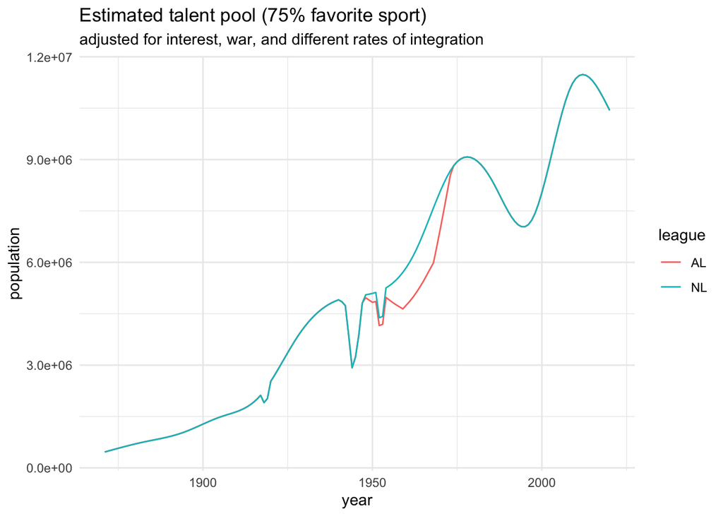

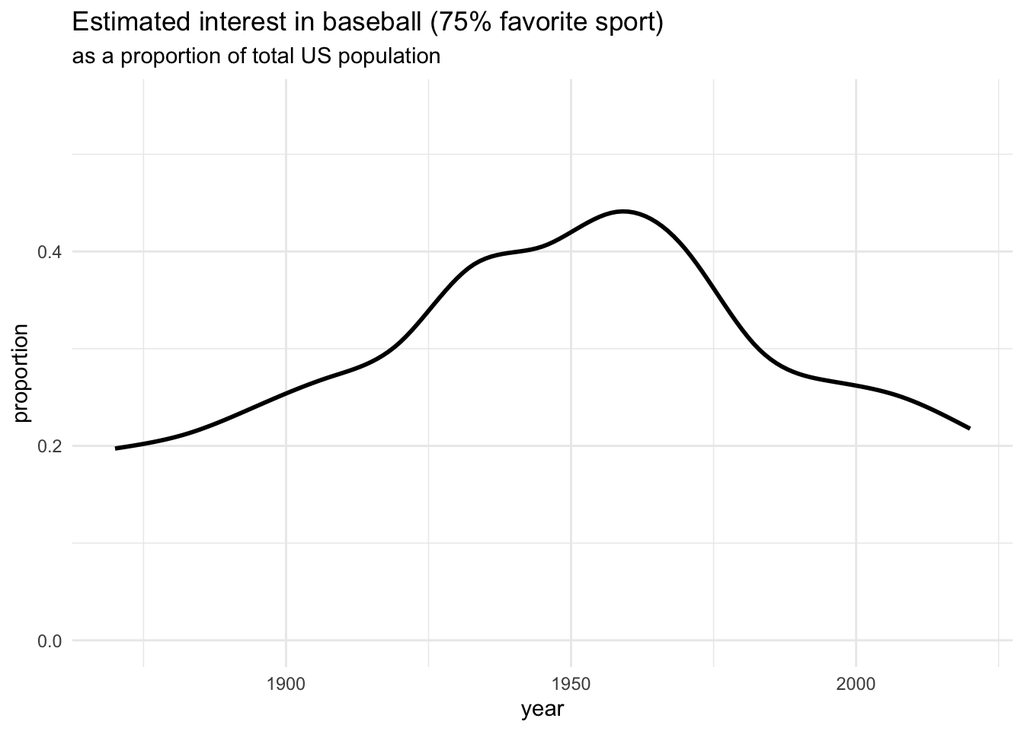

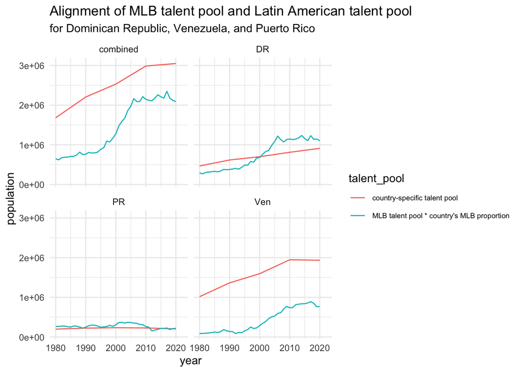

```r
#write_csv(datMLBeligible, "datMLBeligible_0.75_favorite_sport.csv")
#write_csv(dat_interest, "dat_interest_favorite_0.75_sport.csv")
```

### 100% for favorite sport

```r
# 100% for favorite; 0% for general interest
MLB_interest = favorite

# The existence of the MLB itself
MLB_interest = rbind(c(1870,0.20), c(1876, 0.20), c(1886, 0.22), c(1920,0.30),
                      c(1930, 0.38), MLB_interest)
```

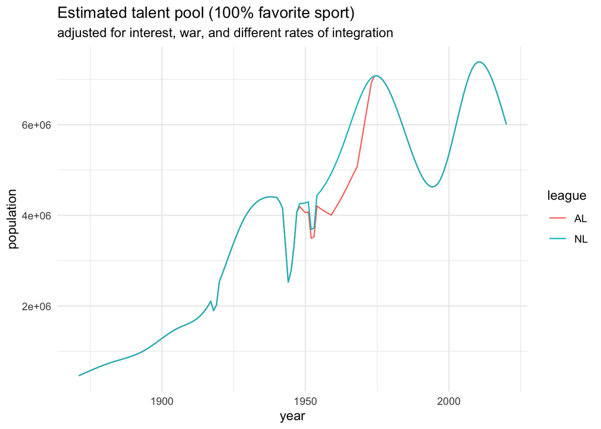

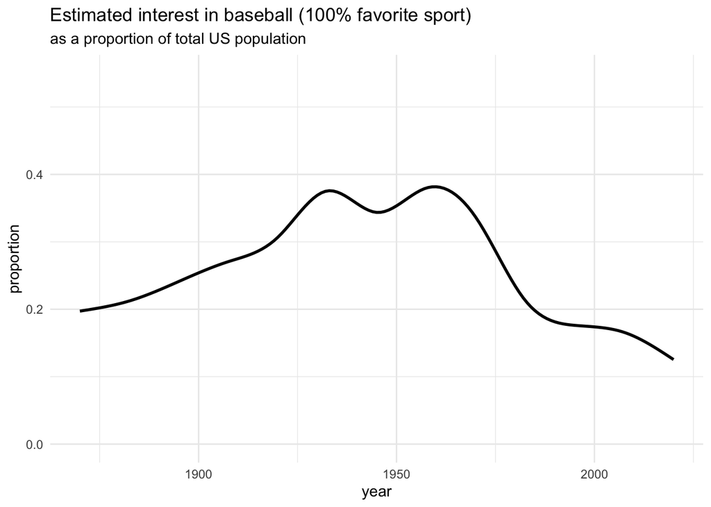

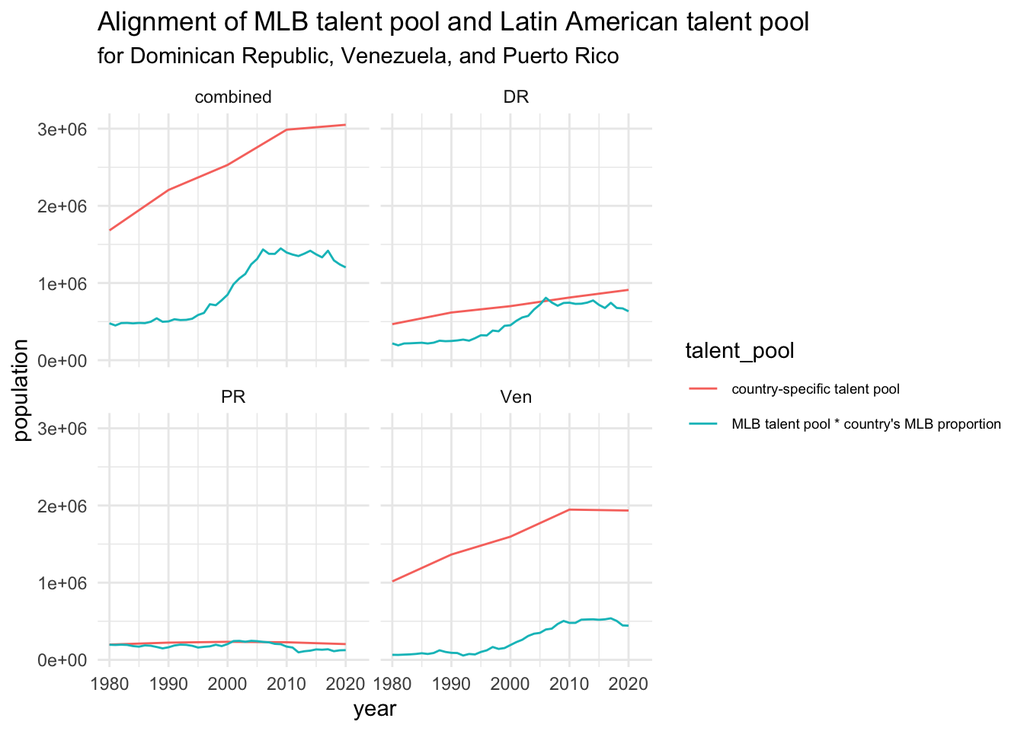

```r
#write_csv(datMLBeligible, "datMLBeligible_favorite_sport.csv")
#write_csv(dat_interest, "dat_interest_favorite_sport.csv")
```

### Interest erodes following erosion of minor leagues

```r
# 50% for favorite; 50% for general interest
MLB_interest = data.frame(
year = 1947:2020,
interest = (approx(favorite$year, favorite$interest, xout = 1947:2020)$y +
              approx(interest$year, interest$interest, xout = 1947:2020,
                     rule = 2)$y)/2
)

# Interest level = 0.9 before 1950
MLB_interest = rbind(cbind("year" = 1870:1949, "interest" = 0.9),
                     MLB_interest[MLB_interest$year >= 1964, ])

dat_interest = data.frame(
  year = 1870:2020,
  interest = approx(MLB_interest$year, MLB_interest$interest, rule = 1,
                    xout = 1870:2020)$y
)
```

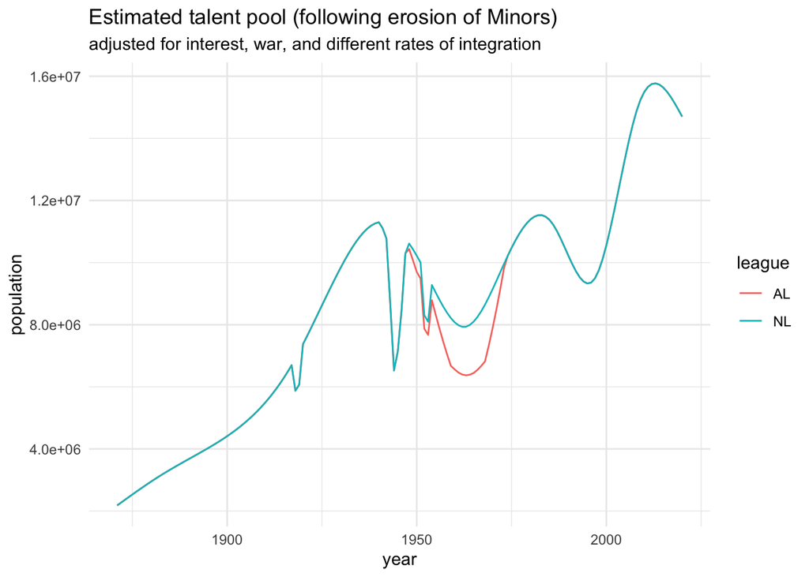

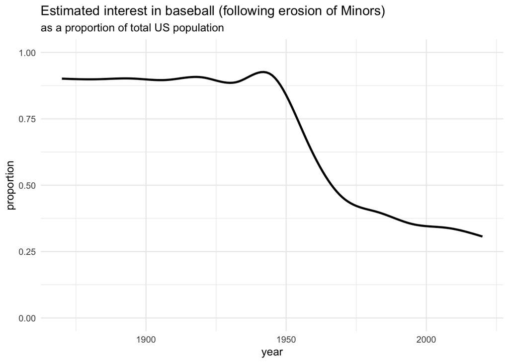

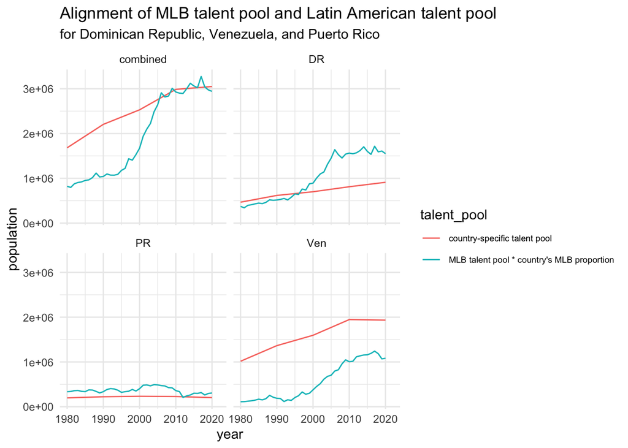

```r
#write_csv(datMLBeligible, "datMLBeligible_erosion.csv")
#write_csv(dat_interest, "dat_interest_erosion.csv")
```